# Social aging in dolphins

Kelley Meehan

2026-09-09

This html documents the final cleaned version of the analysis code used in modeling social aging in dolphins. Analysis was completed in 2026. See software tab for session information.

Created using rmdformats with the downcute theme. https://github.com/juba/rmdformats

# **Setup, load, and create dataset**

## Load packages

```r
# load in packages
library(pacman) # loads and unloads multiple packages in a single line
pacman::p_load(tidyverse, # for dplyr, magrittr, ggplot, etc
               lubridate, # wrangling dates and times
               purrr, # used for reduce(); enhanced programming w/vectors etc
               here, # more flexible way to read in data
               ggh4x, # custom facet capacities for ggplot
               brms, # the man the myth the modelling legend
               parallel, # functions to parallelise modelling for increased speed
               loo, # leave one out cross validation for comparing model fit
               tidybayes, # extracting fits and predictions from brms/rstan models
               ggpubr, # publication ready plots
               broom, # converts model objects into tibbles
               broom.mixed, # broom but for brms type models
               brmsmargins, # emmeans for brms mean dispersion models
               reshape2, # reorganising data i.e. melt()
               coda, # used for HPDinterval
               patchwork, #to lay out figures neatly
               modelr, #for seq.range
               lemon, #for figure arranging
               ggtext, #partial bolding of character strings
               figpatch, #image wrangling into ggplots in conjuction w patchwork
               formatR, #wrapping knitted document
               ggeffects) # creates dataframes of marginal effects

# if needed: check which packages are currently loaded
pacman::p_loaded()
```

```
##  [1] "ggeffects"   "formatR"     "figpatch"    "ggtext"      "lemon"
##  [6] "modelr"      "patchwork"   "coda"        "reshape2"    "brmsmargins"
## [11] "broom.mixed" "broom"       "ggpubr"      "tidybayes"   "loo"
## [16] "brms"        "Rcpp"        "ggh4x"       "here"        "lubridate"
## [21] "forcats"     "stringr"     "dplyr"       "purrr"       "readr"
## [26] "tidyr"       "tibble"      "ggplot2"     "tidyverse"   "pacman"
```

```r
here::i_am("R/socialaging_code_full.Rmd")
```

## Load data

Data comes from the complete dolphin database managed by Georgetown University and was extracted from the database in multiple excel spreadsheets listed below. Each sheet had linking information either in the form of Observation ID or Dolphin ID.

NOTE: This section curates the data and creates the csv file “socialaging_main.csv”. Please note that the provided file has the ID codes anonymised, while parts of this markdown file, which is intended as a visual aid, is not. Locations where code replacements must be made when using the anonymised code have been identified throughout the script.

1. Survey Dolphin (ds) contains data from each survey conducted, including Observation ID, date and times of observation, Dolphin IDs identified in the survey, and other relevant metadata.

```r
# ensure all files are closed before loading
# read in and filter each spreadsheet for the required information

# dolphin survey
ds <- read.csv(here("gu database", "SurveyDolphin_20251208.csv"), header = T, sep = ",") %>%
  # convert obs date to date format
  mutate(Observation.Date = ymd(Observation.Date)) %>%
  # make dolphin id a factor
  mutate(across(where(is.character), factor)) %>%
  # only retain sightings where we are sure of a dolphin's ID
  filter(Dolphin.ID.Certainty == "HIGH") %>%
  # remove sightings that don't follow 10m chain rule
  filter(Beyond.10.Meters.Ind == "False") %>%
  # remove unknown animals
  filter(!Dolphin.ID == "UNKNOWN") %>%
  #we only select needed columns from this file
  select(Observation.ID,
         Observation.Date,
         Dolphin.ID)

# confirm class of each column (should be integer, date, factor)
sapply(ds, class)
```

```
##   Observation.ID Observation.Date       Dolphin.ID
##        "integer"           "Date"         "factor"
```

2. Life History (lh) contains demographic data for each identified dolphin in the database, including birth and death dates or estimates, genetic information if available, sex, parental IDs where known, death date or estimated death date if known or presumed deceased, and other data. This sheet is linked to others via Dolphin ID.

```r
# life history
lh <- read.csv(here("gu database", "LifeHistory_20251208.csv"), header = T, sep = ",") %>%
  #convert to date format
  mutate(Birth.Date = ymd(Birth.Date)) %>%
  #convert to date format
  mutate(Death.Date = ymd(Death.Date)) %>%
  #convert to date format
  mutate(Weaning.Date = ymd(Weaning.Date)) %>%
  #make dolphin id, mother id, father id, haplotype a factor
  mutate(across(where(is.character), factor)) %>%
  select(Dolphin.ID, # linking vector
         Dolphin.Name,
         Sex,
         Sex.Certainty,
         Mother.ID,
         Father.ID, # not needed currently
         Haplotype, # not needed currently
         Birth.Date,
         Death.Date,
         Weaning.Date)

sapply(lh, class)
```

```
##    Dolphin.ID  Dolphin.Name           Sex Sex.Certainty     Mother.ID
##      "factor"      "factor"      "factor"      "factor"      "factor"
##     Father.ID     Haplotype    Birth.Date    Death.Date  Weaning.Date
##      "factor"      "factor"        "Date"        "Date"        "Date"
```

3. Group Overview (gs) describes the metadata of each survey and the known or estimated group sizes of every observation during the scan sample and for the duration of the full observation. This sheet is linked via Observation ID.

```r
# group size
gs <- read.csv(here("gu database", "SurveyGroupOverview_20251208.csv"), header = T, sep = ",") %>%
  mutate(Observation.Date = ymd(Observation.Date)) %>%
  filter(Group.Size.Time.Period == "FIRST FIVE MINUTES")

table(gs$Group.Size.Span)
```

```
##
##       POINT RANGE
## 24814   194   474
```

```r
#replacing NAs with estimates (could be improved)
gs$Group.Size<-ifelse(is.na(gs$Group.Size), gs$Group.Size.Min, gs$Group.Size)
gs$Group.Size<-ifelse(is.na(gs$Group.Size), gs$Group.Size.Max, gs$Group.Size)

gs <- gs %>%
  select(Observation.ID,
         Group.Size,
         # to later count how many groups were range estimates
         Group.Size.Span) %>%
  mutate(Associates = Group.Size - 1) #create response variable

sapply(gs, class)
```

```
##  Observation.ID      Group.Size Group.Size.Span      Associates
##       "integer"       "integer"     "character"       "numeric"
```

## Wrangle datasets and dates

This section merges all unique spreadsheets and uses date and time data to calculate ages of individuals.

```r
# merge dolphin survey and life history tables
dslh <- left_join(ds, lh, by = "Dolphin.ID") #join tables

# calculate age at each observation and weaning age for each dolphin
dslh <- dslh %>%
  mutate(dslh, ObsAge = as.numeric(Observation.Date - Birth.Date, units = "days")) %>%
  #create age of obs and weaning in days
  mutate(dslh, WeanAge = as.numeric(Weaning.Date - Birth.Date, units = "days"))
```

This chunk creates a calf status factor based on known group sizing patterns in females with calves of varying ages. Breaks down individual age into Newborn, Calf, and Non Calf

```r
# calculate average weaning date in this dataset
# this will be used in calculating no calf status for adults
weanmean <- dslh %>%
  group_by(Dolphin.ID) %>%
  summarise(wmean = mean(WeanAge)) %>%
  na.omit()

mean(weanmean$wmean) #1441.463
```

```
## [1] 1441.463
```

```r
dslh <- dslh %>%
  group_by(Dolphin.ID) %>%
  mutate(adj.Wean = case_when(
    is.na(WeanAge) ~ 1441,
    TRUE ~ WeanAge
  ))  %>%
  mutate(Repro.Stat = case_when(
    ObsAge <= 60 ~ "Newborn",
    ObsAge > 60 & ObsAge <= adj.Wean ~ "Calf",
    ObsAge > adj.Wean ~ "Not Calf"
  )) %>%
  select(-adj.Wean)
```

```r
# collapse all sheets into a single dataset
dslhgs <- purrr::reduce(list(dslh, gs), dplyr::left_join, by = "Observation.ID")

# split off year from dates to produce Year for use as a random effect
dslhgs <- dslhgs %>%
  mutate(Year = year(ymd(Observation.Date)))
```

## QA/QC dataset

This section removes incomplete entries and NA values and retains known individuals of known sex and age.

```r
# various filtering and NA removal
dslhgs <- dslhgs %>%
  filter(!Dolphin.ID == "UNKNOWN") %>% #remove the collection of unknown dolphins
  filter(Sex.Certainty == "HIGH") %>% #remove individuals we haven't sexed
  filter(!Sex == "UNKNOWN") %>% #removing the random instead of Certainly Unknown Baguette
  filter(!is.na(Associates)) %>% #removes any NAs
  filter(!is.na(ObsAge)) %>% #removes any animals we don't have age for
  droplevels()

# mitigate temporal autocorrelation by reducing dataset to a single obs per animal per day
dslhgs <- dslhgs %>%
  arrange(desc(Observation.Date)) %>%
  distinct(Observation.Date, Dolphin.ID, .keep_all = TRUE) %>%
  arrange(Observation.Date)
```

## Create ALS (Age Last Sighting) variable

This section identifies the age at last or most recent sighting in order to interact this term with age when incorporating effects of selective disappearance. We thank Reviewers 1 and 3 for advice on this area.

```r
alsdat <- dslhgs %>%
  group_by(Dolphin.ID) %>%
  arrange(desc(ObsAge)) %>%
  slice_head(n=1) %>%
  rename(ALS = ObsAge) %>%
  select(Dolphin.ID,
         ALS) %>%
  droplevels() %>%
  ungroup()

dslhgs <- left_join(dslhgs, alsdat, by = "Dolphin.ID")
```

## Set minimum repeat measures threshold (n ≥ 40)

Predictability requires extensive quantities of repeat measurements for individuals. Based on a review of literature, this study operated on a minimum threshold of 40 repeat measurements per individual.

```r
repmes <- dslhgs %>%
  group_by(Dolphin.ID) %>%
  count(Sex, .drop = FALSE) %>%
  filter(n >= 40) %>%
  mutate(pass = "pass") %>%
  select(-Sex)

# create a pass/fail data column to filter
dslhgs_pass <- left_join(dslhgs, repmes, by = c("Dolphin.ID"))

dslhgs_pass <- dslhgs_pass %>%
   filter(pass == "pass") %>% # create filtered dataset
   ungroup()
```

## Final adjustments

Data wrangling finished with a scaled age variable for modeling and filtering the table for relevant columns

```r
dslhgs_pass <- dslhgs_pass %>%
  mutate(z.Age = as.numeric(scale(ObsAge))) %>%
  mutate(z.ALS = as.numeric(scale(ALS)))

table(dslhgs_pass$Group.Size.Span) # how many ranges vs points/blank (2320)
```

```
##
##       POINT RANGE
## 61544  1050  2320
```

```r
final_data <- dslhgs_pass %>%
  droplevels() %>% #remove levels of any factor emptied during this cleanup
  select(Observation.ID,
         Observation.Date,
         Year,
         Dolphin.ID,
         Sex,
         ObsAge,
         z.Age,
         ALS,
         z.ALS,
         Repro.Stat,
         Associates)
```

Check completed spreadsheet and export

```r
write.csv(final_data, "data/data_socialaging_13032025.csv", row.names = FALSE)
```

This version is the anonymised version provided publicly. This anonymisation aligned with anonymised codes in the SBDRP data github. Replace “Dolphin.ID” with “anon_id” to use throughout this code.

```r
anon <- read.csv(here("gu database", "lh_with_anon_id.csv"), header = T, sep = ",") %>%
  select(Dolphin.ID,
         anon_id)

anon_data <- final_data %>%
  left_join(anon, by = "Dolphin.ID")

anon_data <- anon_data %>%
  select(-Dolphin.ID)

#write.csv(anon_data, "data/socialaging_main.csv", row.names = FALSE)
```

# **Complete dataset**

```r
head(final_data, 10)
```

| Observation.ID | Observation.Date | Year | Dolphin.ID | Sex | ObsAge | z.Age | ALS | z.ALS | Repro.Stat | Associates |
| --- | --- | --- | --- | --- | --- | --- | --- | --- | --- | --- |
| 711 | 1988-06-22 | 1988 | SQL | FEMALE | 1329 | -1.2900322 | 3608 | -1.84015047 | Calf | 1 |
| 711 | 1988-06-22 | 1988 | SQU | FEMALE | 7173 | 0.2025655 | 12339 | 0.40864586 | Not Calf | 1 |
| 714 | 1988-06-23 | 1988 | CRI | MALE | 9731 | 0.8558962 | 11511 | 0.19538239 | Not Calf | 1 |
| 714 | 1988-06-23 | 1988 | SLA | MALE | 8270 | 0.4827468 | 9512 | -0.31948920 | Not Calf | 1 |
| 715 | 1988-06-23 | 1988 | UHF | FEMALE | 7540 | 0.2962998 | 12918 | 0.55777575 | Not Calf | 1 |
| 717 | 1988-06-30 | 1988 | HOL | FEMALE | 10103 | 0.9509075 | 12686 | 0.49802077 | Not Calf | 0 |
| 718 | 1988-06-30 | 1988 | YAN | FEMALE | 5720 | -0.1685407 | 9219 | -0.39495562 | Not Calf | 1 |
| 718 | 1988-06-30 | 1988 | YIN | FEMALE | 1337 | -1.2879889 | 4485 | -1.61426633 | Calf | 1 |
| 719 | 1988-06-30 | 1988 | JFR | FEMALE | 3529 | -0.7281371 | 10494 | -0.06656079 | Not Calf | 0 |
| 720 | 1988-07-01 | 1988 | CRO | FEMALE | 10104 | 0.9511629 | 11362 | 0.15700527 | Not Calf | 0 |

# **Data Exploration**

## Response distribution by sex

```r
#load exported data (for when starting a new script or working from a different device)
dat <- read.csv(here("data", "data_socialaging_13032026.csv"), header = TRUE, sep = ",") %>%
  mutate(across(where(is.character), factor))

# for anonymised data
# dat <- read.csv(here("data", "socialaging_main.csv"), header = TRUE, sep = ",") %>%
#   mutate(across(where(is.character), factor))

#split into sexes
females <- dat %>%
  filter(Sex == "FEMALE") %>%
  droplevels()

males <- dat %>%
  filter(Sex == "MALE") %>%
  droplevels()
```

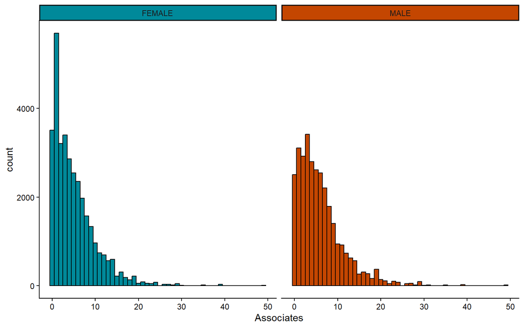

```r
sstrip <- strip_themed(background_x = elem_list_rect(fill = c("#00899a","#c44601"),
                                                       color = c("black", "black")))
sex_hist <- ggplot(dat,
                   aes(x = Associates,
                       fill = Sex,
                       colour = Sex)) +
  geom_histogram(position = "identity", binwidth = 1) +
  scale_fill_manual(values = c("#00899a","#c44601")) +
  scale_colour_manual(values = c("black", "black")) +
  theme_classic() +
  theme(legend.position = "none",
        panel.background = element_rect(fill = "transparent"),
        plot.background = element_rect(fill = "transparent",
                                       color = NA)) +
  facet_wrap2(~Sex, strip = sstrip)

sex_hist
```

## Response distribution by age of individual at sighting

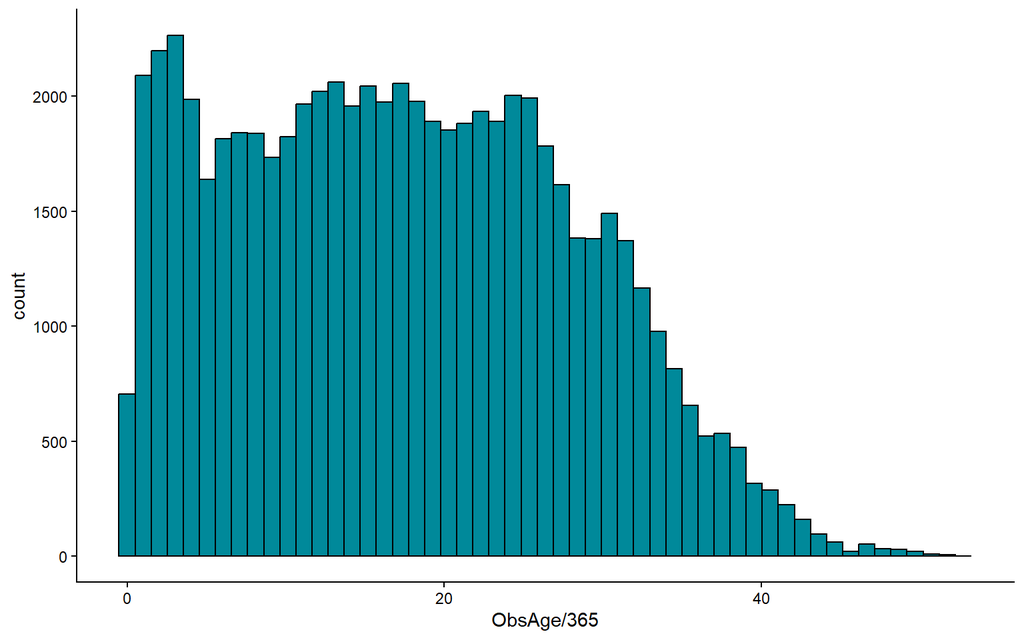

```r
agehist <- ggplot(dat,
                  aes(x = ObsAge/365)) +
  geom_histogram(bins = 53, position = "identity", fill = "#00899a", colour = "black") +
  theme_classic() +
  theme(legend.position = "none",
        panel.background = element_rect(fill = "transparent"),
        plot.background = element_rect(fill = "transparent",
                                       color = NA))

agehist
```

```r
agebins <- dat %>%
  mutate(yearage = ObsAge/365)

agebins <- floor(agebins$yearage)

table(agebins)
```

```
## agebins
##    0    1    2    3    4    5    6    7    8    9   10   11   12   13   14   15
## 2141 2118 2281 2054 1681 1809 1811 1741 1726 1753 1854 1973 2026 1934 2075 1918
##   16   17   18   19   20   21   22   23   24   25   26   27   28   29   30   31
## 1931 1903 1976 1783 1844 1853 1853 1869 2004 1893 1699 1529 1327 1394 1461 1332
##   32   33   34   35   36   37   38   39   40   41   42   43   44   45   46   47
## 1122  941  796  645  500  535  446  359  271  232  157  105   72   29   50   33
##   48   49   50   51   52
##   26   25   11    9    4
```

## Response effect of sex

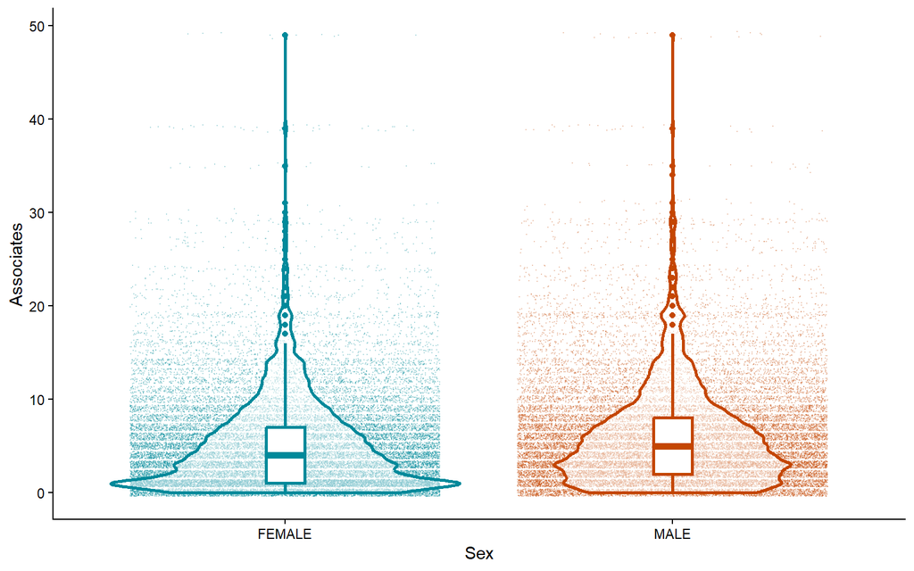

```r
sex_plot <- ggplot(dat,
                   aes(x = Sex,
                       y = Associates,
                       colour = Sex)) +
  geom_jitter(size = 0.1,
              alpha = 0.2) +
  geom_violin(linewidth = 1,
              alpha = 0.5) +
  geom_boxplot(width = 0.1,
               linewidth = 1) +
  scale_color_manual(values = c("#00899a","#c44601")) +
  theme_classic() +
  theme(legend.position = "none",
        panel.background = element_rect(fill = "transparent"),
        plot.background = element_rect(fill = "transparent",
                                       color = NA))
sex_plot
```

## Response effect of reproductive status

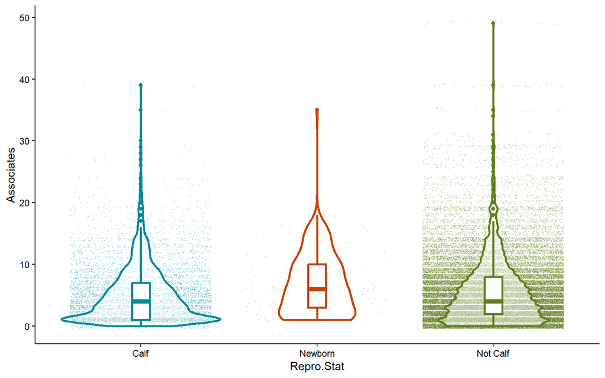

```r
repro_plot <- ggplot(dat,
                   aes(x = Repro.Stat,
                       y = Associates,
                       colour = Repro.Stat)) +
  geom_jitter(size = 0.1,
              alpha = 0.2) +
  geom_violin(linewidth = 1,
              alpha = 0.5) +
  geom_boxplot(width = 0.1,
               linewidth = 1) +
  scale_color_manual(values = c("#00899a","#c44601", "#607d1c")) +
  theme_classic() +
  theme(legend.position = "none",
        panel.background = element_rect(fill = "transparent"),
        plot.background = element_rect(fill = "transparent",
                                       color = NA))
repro_plot
```

## Response effect of age

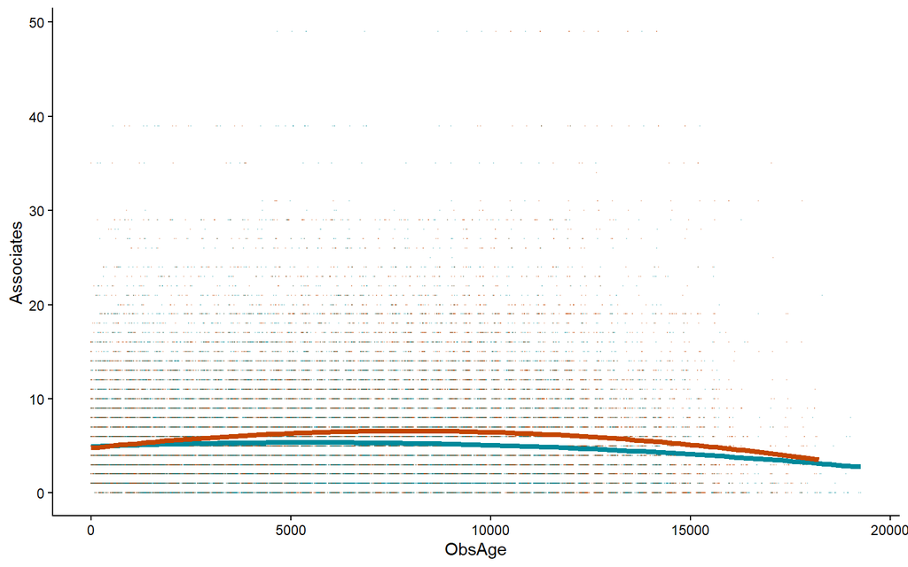

```r
age_plot <- ggplot(dat,
                   aes(x = ObsAge,
                       y = Associates,
                       color = Sex)) +
  geom_point(size = 0.1,
             alpha = 0.2) +
  geom_smooth(method = "gam", formula = y~poly(x,2), se = F,
              linewidth = 1.5) +
  scale_color_manual(values = c("#00899a","#c44601")) +
    theme_classic() +
    theme(legend.position = "none",
          panel.background = element_rect(fill = "transparent"),
          plot.background = element_rect(fill = "transparent",
                                       color = NA))

age_plot
```

## Yearly breakdown

```r
#create table of information about individuals and observations per year
peryear = aggregate(x = dat$Dolphin.ID, by = list(dat$Year), function (x) length(unique(x)))
names(peryear) = c("Year", "Number of Individuals") #individuals per year

obsperyear = aggregate(x = dat$Observation.ID, by = list(dat$Year), function(x) length(unique(x)))
names(obsperyear) = c("Year", "Number of Observations") #observations per year

peryear <- left_join(peryear, obsperyear, by = "Year")

peryear
```

| Year | Number of Individuals | Number of Observations |
| --- | --- | --- |
| 1988 | 40 | 43 |
| 1989 | 73 | 136 |
| 1990 | 117 | 529 |
| 1991 | 128 | 622 |
| 1992 | 123 | 260 |
| 1993 | 152 | 460 |
| 1994 | 164 | 382 |
| 1995 | 135 | 256 |
| 1996 | 210 | 588 |
| 1997 | 238 | 766 |

[output cut: 26 more lines]

```r
# average number of years sighted
years.sighted <- dat %>%
  count(Dolphin.ID, Year) %>%
  count(Dolphin.ID)

mean(years.sighted$n); range(years.sighted$n)
```

```
## [1] 17.29322
```

```
## [1]  3 35
```

## Sex breakdown

```r
# this informs much of table S2
meanobs <- dat %>%
  group_by(Dolphin.ID, Sex) %>%
  summarise(Count = n()) %>%
  ungroup()

meanobs <- meanobs %>%
  mutate(Meanobs = mean(Count))

meanobs <- meanobs %>%
  group_by(Sex) %>%
  mutate(MFmeanobs = mean(Count)) %>%
  mutate(MFstderrobs = (sd(Count)/sqrt(length(unique(Dolphin.ID))))) %>%
  ungroup() %>%
  mutate(stderrobs = sd(Count)/sqrt(length(unique(Dolphin.ID)))) %>%
  select(Sex,
         Meanobs,
         stderrobs,
         MFmeanobs,
         MFstderrobs) %>%
  distinct(Sex, .keep_all = TRUE)

meanobs
```

| Sex | Meanobs | stderrobs | MFmeanobs | MFstderrobs |
| --- | --- | --- | --- | --- |
| MALE | 142.0438 | 6.885697 | 137.2237 | 8.582539 |
| FEMALE | 142.0438 | 6.885697 | 146.8428 | 10.771169 |

```r
#for min and max obs
datrange <- dat %>%
  group_by(Dolphin.ID) %>%
  count(Dolphin.ID)

# sex

males = dat[dat$Sex=="MALE",]
females = dat[dat$Sex=="FEMALE",]

length(unique(dat$Dolphin.ID)) #457
```

```
## [1] 457
```

```r
length(unique(males$Dolphin.ID)) #228
```

```
## [1] 228
```

```r
length(unique(females$Dolphin.ID)) #229
```

```
## [1] 229
```

```r
# associates mean/sd

mean(dat$Associates); sd(dat$Associates)
```

```
## [1] 5.578904
```

```
## [1] 5.198102
```

```r
mean(males$Associates); sd(males$Associates)
```

```
## [1] 6.051395
```

```
## [1] 5.36504
```

```r
mean(females$Associates); sd(females$Associates)
```

```
## [1] 5.139293
```

```
## [1] 4.99794
```

# **Models**

## Set up parallel processing

```r
# ensure this is customised to specific system
# this is geared for a windows OS using R shortstop beagle 4.2.3
if (Sys.getenv("RSTUDIO") == "1" && !nzchar(Sys.getenv("RSTUDIO_TERM")) &&
    Sys.info()["sysname"] == "Windows" && getRversion() == "4.2.3") {
  parallel:::setDefaultClusterOptions(setup_strategy = "sequential")
}
```

## Create prior

Note: Stan-dev recommends approximating Penalised Complexity priors for the shape parameter in negative binomial models when measuring dispersion. Best practice approximation is inverse gamma(0.4,0,3). Further information can be found here: https://users.aalto.fi/~ave/casestudies/Priors/negbinomial_shape_prior.html

```r
pcprior <- c(prior_string("inv_gamma(0.4,0.3)",
                          class = "sd",
                          dpar = "shape"), # dispersion parameter: varies by family
             prior_string("inv_gamma(0.4,0.3)",
                          class = "b",
                          coef = "",
                          dpar = "shape",
                          lb = 0))
```

## Subset data

Note: these models are computationally heavy and time-consuming, ranging in processing time from 12-72+ hours per model. Initial models were thus run using a subset of the data to make comparisons, and the best fit models were run using the full dataset compared using pp_check and loo criterion. Selection was made based on parsimony and fit.

```r
sampledat <- dat[sample(1:nrow(dat), 10000, replace = FALSE),]

head(sampledat, 10)
```

|  | Observation.ID | Observation.Date | Year | Dolphin.ID | Sex | ObsAge | z.Age | ALS | z.ALS | Repro.Stat | Associates |
| --- | --- | --- | --- | --- | --- | --- | --- | --- | --- | --- | --- |
| 54697 | 21693 | 2016-06-12 | 2016 | KIY | FEMALE | 6756 | 0.09606082 | 10101 | -0.16778367 | Not Calf | 1 |
| 7547 | 4011 | 1994-08-23 | 1994 | JIM | MALE | 7965 | 0.40484770 | 15315 | 1.17515804 | Not Calf | 6 |
| 52721 | 20928 | 2015-07-30 | 2015 | BUD | MALE | 4573 | -0.46149234 | 7421 | -0.85805673 | Not Calf | 4 |
| 27169 | 11482 | 2002-09-18 | 2002 | SMO | MALE | 5009 | -0.35013495 | 13327 | 0.66311966 | Not Calf | 5 |
| 9390 | 4637 | 1996-08-01 | 1996 | CAM | MALE | 620 | -1.47111561 | 1287 | -2.43795785 | Calf | 0 |
| 21395 | 9129 | 2001-04-15 | 2001 | SKF | FEMALE | 2357 | -1.02747392 | 11218 | 0.11991597 | Not Calf | 3 |
| 30062 | 12495 | 2003-07-13 | 2003 | HHD | MALE | 4637 | -0.44514630 | 6455 | -1.10686411 | Not Calf | 7 |
| 20358 | 8767 | 2000-08-22 | 2000 | ZIP | FEMALE | 5043 | -0.34145112 | 10948 | 0.05037353 | Not Calf | 5 |
| 15211 | 6656 | 1998-07-18 | 1998 | NIP | FEMALE | 10121 | 0.95550487 | 11609 | 0.22062372 | Not Calf | 1 |
| 32467 | 13366 | 2004-05-14 | 2004 | SPE | FEMALE | 4517 | -0.47579512 | 12307 | 0.40040379 | Not Calf | 3 |

## Model building

### No interaction, SZiL/D

```r
# no interaction, linear sex, zage*als fixeffs, only Dolphin ID raneffs
DHGLM_Fszilp_Rd <- bf(Associates ~
                        Sex + z.Age*z.ALS + Repro.Stat + (1|a|Dolphin.ID),
                      shape ~ Sex + z.Age*z.ALS + Repro.Stat + (1|a|Dolphin.ID))

fit_Fszilp_Rd <- brm(DHGLM_Fszilp_Rd,
                   data = sampledat,
                   family = negbinomial(link = "log", link_shape = "log"),
                   prior = pcprior,
                   iter = 5000,
                   warmup = 3000,
                   thin = 1,
                   chains = 2,
                   cores = 2,
                   threads = threading(10),
                   seed = 0920,
                   file = "fits/fit_Fszilp_Rd.rds")

fit_Fszilp_Rd <-add_criterion(fit_Fszilp_Rd, "loo")
```

```r
summary(fit_Fszilp_Rd)
```

```
##  Family: negbinomial
##   Links: mu = log; shape = log
## Formula: Associates ~ Sex + z.Age * z.ALS + Repro.Stat + (1 | a | Dolphin.ID)
##          shape ~ Sex + z.Age * z.ALS + Repro.Stat + (1 | a | Dolphin.ID)
##    Data: sampledat (Number of observations: 10000)
##   Draws: 2 chains, each with iter = 5000; warmup = 3000; thin = 1;
##          total post-warmup draws = 4000
##
## Multilevel Hyperparameters:
## ~Dolphin.ID (Number of levels: 457)
##                                Estimate Est.Error l-95% CI u-95% CI Rhat
## sd(Intercept)                      0.26      0.02     0.23     0.29 1.00
## sd(shape_Intercept)                0.46      0.03     0.39     0.52 1.00
## cor(Intercept,shape_Intercept)     0.50      0.08     0.33     0.66 1.00
##                                Bulk_ESS Tail_ESS
## sd(Intercept)                      1624     2791
## sd(shape_Intercept)                2038     2911
## cor(Intercept,shape_Intercept)     1542     2470
##
## Regression Coefficients:
##                         Estimate Est.Error l-95% CI u-95% CI Rhat Bulk_ESS
## Intercept                   1.61      0.20     1.21     2.01 1.00     6215
## shape_Intercept             0.10      0.11    -0.16     0.27 1.00     5528
## SexMALE                     0.19      0.03     0.13     0.26 1.00     3101
## z.Age                      -0.01      0.02    -0.05     0.02 1.00     5436
## z.ALS                       0.01      0.02    -0.03     0.05 1.00     3552
## Repro.StatCalf             -0.13      0.20    -0.52     0.26 1.00     6376
## Repro.StatNotCalf          -0.01      0.20    -0.41     0.39 1.00     6211
## z.Age:z.ALS                -0.04      0.02    -0.07    -0.01 1.00     3854
## shape_SexMALE               0.27      0.06     0.16     0.40 1.00     4228
## shape_z.Age                 0.03      0.01     0.02     0.04 1.00    10503
## shape_z.ALS                 0.07      0.02     0.04     0.11 1.00     6126
## shape_Repro.StatCalf        0.46      0.12     0.26     0.74 1.00     6390
## shape_Repro.StatNotCalf     0.19      0.10     0.06     0.44 1.00     6560
## shape_z.Age:z.ALS           0.03      0.01     0.02     0.04 1.00    11816
##                         Tail_ESS
## Intercept                   2993
## shape_Intercept             2882
## SexMALE                     3396
## z.Age                       3639
## z.ALS                       3259
## Repro.StatCalf              3008
## Repro.StatNotCalf           3080
## z.Age:z.ALS                 3419
## shape_SexMALE               3020
## shape_z.Age                 2715
## shape_z.ALS                 3180
## shape_Repro.StatCalf        3317
## shape_Repro.StatNotCalf     3342
## shape_z.Age:z.ALS           2727
##
## Draws were sampled using sampling(NUTS). For each parameter, Bulk_ESS
## and Tail_ESS are effective sample size measures, and Rhat is the potential
## scale reduction factor on split chains (at convergence, Rhat = 1).
```

### No interaction, SZiL/DY

```r
DHGLM_Fszilp_Rdy <- bf(Associates ~
                        Sex + z.Age*z.ALS + Repro.Stat + (1|a|Dolphin.ID) + (1|b|Year),
                      shape ~ Sex + z.Age*z.ALS + Repro.Stat + (1|a|Dolphin.ID) + (1|b|Year))

fit_Fszilp_Rdy <- brm(DHGLM_Fszilp_Rdy,
                   data = sampledat,
                   family = negbinomial(link = "log", link_shape = "log"),
                   prior = pcprior,
                   iter = 5000,
                   warmup = 3000,
                   thin = 1,
                   chains = 2,
                   cores = 2,
                   init = 1,
                   threads = threading(10),
                   seed = 0920,
                   file = "fits/fit_Fszilp_Rdy.rds")

fit_Fszilp_Rdy <-add_criterion(fit_Fszilp_Rdy, "loo")
```

```r
summary(fit_Fszilp_Rdy)
```

```
##  Family: negbinomial
##   Links: mu = log; shape = log
## Formula: Associates ~ Sex + z.Age * z.ALS + Repro.Stat + (1 | a | Dolphin.ID) + (1 | b | Year)
##          shape ~ Sex + z.Age * z.ALS + Repro.Stat + (1 | a | Dolphin.ID) + (1 | b | Year)
##    Data: sampledat (Number of observations: 10000)
##   Draws: 2 chains, each with iter = 5000; warmup = 3000; thin = 1;
##          total post-warmup draws = 4000
##
## Multilevel Hyperparameters:
## ~Dolphin.ID (Number of levels: 457)
##                                Estimate Est.Error l-95% CI u-95% CI Rhat
## sd(Intercept)                      0.25      0.02     0.22     0.28 1.00
## sd(shape_Intercept)                0.45      0.03     0.38     0.51 1.00
## cor(Intercept,shape_Intercept)     0.62      0.08     0.45     0.77 1.00
##                                Bulk_ESS Tail_ESS
## sd(Intercept)                      1424     2353
## sd(shape_Intercept)                1767     2384
## cor(Intercept,shape_Intercept)      878     1559
##
## ~Year (Number of levels: 36)
##                                Estimate Est.Error l-95% CI u-95% CI Rhat
## sd(Intercept)                      0.14      0.02     0.10     0.19 1.00
## sd(shape_Intercept)                0.39      0.06     0.29     0.51 1.00
## cor(Intercept,shape_Intercept)     0.27      0.19    -0.12     0.60 1.00
##                                Bulk_ESS Tail_ESS
## sd(Intercept)                      1355     2170
## sd(shape_Intercept)                1607     2395
## cor(Intercept,shape_Intercept)      744     1254
##
## Regression Coefficients:
##                         Estimate Est.Error l-95% CI u-95% CI Rhat Bulk_ESS
## Intercept                   1.57      0.18     1.22     1.94 1.00     2596
## shape_Intercept             0.11      0.14    -0.21     0.34 1.00     1649
## SexMALE                     0.19      0.03     0.12     0.25 1.00     1417
## z.Age                      -0.00      0.02    -0.04     0.04 1.00     1405
## z.ALS                       0.01      0.02    -0.04     0.05 1.00     1109
## Repro.StatCalf             -0.11      0.18    -0.47     0.23 1.00     2902
## Repro.StatNotCalf           0.02      0.18    -0.35     0.36 1.00     2894
## z.Age:z.ALS                -0.03      0.02    -0.06    -0.00 1.00     2160
## shape_SexMALE               0.26      0.06     0.15     0.39 1.00     2422
```

[output cut: 9 more lines]

```
## z.Age                       2308
## z.ALS                       1961
## Repro.StatCalf              2740
## Repro.StatNotCalf           2786
## z.Age:z.ALS                 2976
## shape_SexMALE               2668
## shape_z.Age                 2983
## shape_z.ALS                 2590
## shape_Repro.StatCalf        2526
## shape_Repro.StatNotCalf     2725
## shape_z.Age:z.ALS           3290
##
## Draws were sampled using sampling(NUTS). For each parameter, Bulk_ESS
## and Tail_ESS are effective sample size measures, and Rhat is the potential
## scale reduction factor on split chains (at convergence, Rhat = 1).
```

### no interaction, SZiL/DYO

```r
DHGLM_Fszilp_Rdyo <- bf(Associates ~
                        Sex + z.Age*z.ALS + (1|a|Dolphin.ID) + Repro.Stat + (1|b|Year) + (1|c|Observation.Date),
                      shape ~ Sex + z.Age*z.ALS + (1|a|Dolphin.ID) + Repro.Stat + (1|b|Year) + (1|c|Observation.Date))

fit_Fszilp_Rdyo <- brm(DHGLM_Fszilp_Rdyo,
                   data = sampledat,
                   family = negbinomial(link = "log", link_shape = "log"),
                   prior = pcprior,
                   iter = 5000,
                   warmup = 3000,
                   thin = 1,
                   chains = 2,
                   cores = 2,
                   threads = threading(10),
                   seed = 0920,
                   file = "fits/fit_Fszilp_Rdyo.rds")

fit_Fszilp_Rdyo <-add_criterion(fit_Fszilp_Rdyo, "loo")
```

```r
summary(fit_Fszilp_Rdyo)
```

```
##  Family: negbinomial
##   Links: mu = log; shape = log
## Formula: Associates ~ Sex + z.Age * z.ALS + (1 | a | Dolphin.ID) + Repro.Stat + (1 | b | Year) + (1 | c | Observation.Date)
##          shape ~ Sex + z.Age * z.ALS + (1 | a | Dolphin.ID) + Repro.Stat + (1 | b | Year) + (1 | c | Observation.Date)
##    Data: sampledat (Number of observations: 10000)
##   Draws: 2 chains, each with iter = 5000; warmup = 3000; thin = 1;
##          total post-warmup draws = 4000
##
## Multilevel Hyperparameters:
## ~Dolphin.ID (Number of levels: 457)
##                                Estimate Est.Error l-95% CI u-95% CI Rhat
## sd(Intercept)                      0.18      0.01     0.15     0.21 1.00
## sd(shape_Intercept)                0.81      0.06     0.70     0.92 1.00
## cor(Intercept,shape_Intercept)     0.93      0.04     0.83     1.00 1.01
##                                Bulk_ESS Tail_ESS
## sd(Intercept)                      2065     2908
## sd(shape_Intercept)                1945     2903
## cor(Intercept,shape_Intercept)      432      905
##
## ~Observation.Date (Number of levels: 2872)
##                                Estimate Est.Error l-95% CI u-95% CI Rhat
## sd(Intercept)                      0.51      0.01     0.48     0.53 1.00
## sd(shape_Intercept)                0.99      0.06     0.87     1.12 1.00
## cor(Intercept,shape_Intercept)    -0.07      0.06    -0.19     0.05 1.00
##                                Bulk_ESS Tail_ESS
## sd(Intercept)                      1438     1894
## sd(shape_Intercept)                1245     2486
## cor(Intercept,shape_Intercept)     1695     2600
##
## ~Year (Number of levels: 36)
##                                Estimate Est.Error l-95% CI u-95% CI Rhat
## sd(Intercept)                      0.13      0.02     0.09     0.19 1.00
## sd(shape_Intercept)                0.58      0.09     0.42     0.79 1.00
## cor(Intercept,shape_Intercept)     0.39      0.21    -0.05     0.75 1.00
##                                Bulk_ESS Tail_ESS
## sd(Intercept)                      1835     2515
## sd(shape_Intercept)                2210     3088
## cor(Intercept,shape_Intercept)     1415     2188
##
## Regression Coefficients:
```

[output cut: 19 more lines]

```
## z.Age                       3190
## z.ALS                       2718
## Repro.StatCalf              3189
## Repro.StatNotCalf           3260
## z.Age:z.ALS                 3129
## shape_SexMALE               2687
## shape_z.Age                 2788
## shape_z.ALS                 3435
## shape_Repro.StatCalf        2967
## shape_Repro.StatNotCalf     3152
## shape_z.Age:z.ALS           2570
##
## Draws were sampled using sampling(NUTS). For each parameter, Bulk_ESS
## and Tail_ESS are effective sample size measures, and Rhat is the potential
## scale reduction factor on split chains (at convergence, Rhat = 1).
```

### no interaction, SVpolyZiL/DYO

```r
DHGLM_Fsz2ilp_Rdyo <- bf(Associates ~
                          1 + Sex + poly(z.Age,2)*z.ALS + Repro.Stat + (1|a|Dolphin.ID) + (1|b|Year) + (1|c|Observation.Date),
                        shape ~ Sex + z.Age*z.ALS + Repro.Stat + (1|a|Dolphin.ID) + (1|b|Year) + (1|c|Observation.Date))

fit_Fsz2ilp_Rdyo <- brm(DHGLM_Fsz2ilp_Rdyo,
                      data = sampledat,
                      family = negbinomial(link = "log", link_shape = "log"),
                      prior = pcprior,
                      iter = 5000,
                      warmup = 3000,
                      thin = 1,
                      chains = 2,
                      cores = 2,
                      threads = threading(10),
                      seed = 0920,
                      file = "fits/fit_Fsz2ilp_Rdyo.rds")

fit_Fsz2ilp_Rdyo <-add_criterion(fit_Fsz2ilp_Rdyo, "loo")
```

```r
summary(fit_Fsz2ilp_Rdyo)
```

```
##  Family: negbinomial
##   Links: mu = log; shape = log
## Formula: Associates ~ 1 + Sex + poly(z.Age, 2) * z.ALS + Repro.Stat + (1 | a | Dolphin.ID) + (1 | b | Year) + (1 | c | Observation.Date)
##          shape ~ Sex + z.Age * z.ALS + Repro.Stat + (1 | a | Dolphin.ID) + (1 | b | Year) + (1 | c | Observation.Date)
##    Data: sampledat (Number of observations: 10000)
##   Draws: 2 chains, each with iter = 5000; warmup = 3000; thin = 1;
##          total post-warmup draws = 4000
##
## Multilevel Hyperparameters:
## ~Dolphin.ID (Number of levels: 457)
##                                Estimate Est.Error l-95% CI u-95% CI Rhat
## sd(Intercept)                      0.18      0.01     0.15     0.21 1.00
## sd(shape_Intercept)                0.80      0.06     0.69     0.92 1.00
## cor(Intercept,shape_Intercept)     0.94      0.04     0.84     1.00 1.00
##                                Bulk_ESS Tail_ESS
## sd(Intercept)                      1696     2878
## sd(shape_Intercept)                1983     2796
## cor(Intercept,shape_Intercept)      474     1118
##
## ~Observation.Date (Number of levels: 2872)
##                                Estimate Est.Error l-95% CI u-95% CI Rhat
## sd(Intercept)                      0.51      0.01     0.48     0.53 1.00
## sd(shape_Intercept)                0.98      0.06     0.86     1.11 1.00
## cor(Intercept,shape_Intercept)    -0.09      0.06    -0.21     0.02 1.00
##                                Bulk_ESS Tail_ESS
## sd(Intercept)                       984     2114
## sd(shape_Intercept)                1216     1868
## cor(Intercept,shape_Intercept)     1812     2469
##
## ~Year (Number of levels: 36)
##                                Estimate Est.Error l-95% CI u-95% CI Rhat
## sd(Intercept)                      0.14      0.02     0.09     0.19 1.00
## sd(shape_Intercept)                0.57      0.10     0.41     0.79 1.00
## cor(Intercept,shape_Intercept)     0.35      0.21    -0.10     0.71 1.00
##                                Bulk_ESS Tail_ESS
## sd(Intercept)                      1691     2398
## sd(shape_Intercept)                2051     2585
## cor(Intercept,shape_Intercept)     1050     1604
##
## Regression Coefficients:
```

[output cut: 23 more lines]

```
## z.ALS                       2602
## Repro.StatCalf              2985
## Repro.StatNotCalf           2460
## polyz.Age21:z.ALS           3030
## polyz.Age22:z.ALS           3146
## shape_SexMALE               2742
## shape_z.Age                 3154
## shape_z.ALS                 3318
## shape_Repro.StatCalf        3169
## shape_Repro.StatNotCalf     3139
## shape_z.Age:z.ALS           2929
##
## Draws were sampled using sampling(NUTS). For each parameter, Bulk_ESS
## and Tail_ESS are effective sample size measures, and Rhat is the potential
## scale reduction factor on split chains (at convergence, Rhat = 1).
```

### no interaction, SVpolyZiL/polyZLDYO

```r
DHGLM_Fsz2ilp_Rz2ldyo <- bf(Associates ~
                          1 + Sex + poly(z.Age,2)*z.ALS + Repro.Stat + (poly(z.Age,2)|a|Dolphin.ID) + (1|b|Year) + (1|c|Observation.Date),
                        shape ~ Sex + z.Age*z.ALS + Repro.Stat + (1|a|Dolphin.ID) + (1|b|Year) + (1|c|Observation.Date))

fit_Fsz2ilp_Rz2ldyo <- brm(DHGLM_Fsz2ilp_Rz2ldyo,
                   data = sampledat,
                   family = negbinomial(link = "log", link_shape = "log"),
                   prior = pcprior,
                   iter = 5000,
                   warmup = 3000,
                   thin = 1,
                   chains = 2,
                   cores = 2,
                   threads = threading(10),
                   seed = 0920,
                   file = "fits/fit_Fsz2ilp_Rz2ldyo.rds")

fit_Fsz2ilp_Rz2ldyo <-add_criterion(fit_Fsz2ilp_Rz2ldyo, "loo")
```

```r
summary(fit_Fsz2ilp_Rz2ldyo)
```

```
##  Family: negbinomial
##   Links: mu = log; shape = log
## Formula: Associates ~ 1 + Sex + poly(z.Age, 2) * z.ALS + Repro.Stat + (poly(z.Age, 2) | a | Dolphin.ID) + (1 | b | Year) + (1 | c | Observation.Date)
##          shape ~ Sex + z.Age * z.ALS + Repro.Stat + (1 | a | Dolphin.ID) + (1 | b | Year) + (1 | c | Observation.Date)
##    Data: sampledat (Number of observations: 10000)
##   Draws: 2 chains, each with iter = 5000; warmup = 3000; thin = 1;
##          total post-warmup draws = 4000
##
## Multilevel Hyperparameters:
## ~Dolphin.ID (Number of levels: 457)
##                                  Estimate Est.Error l-95% CI u-95% CI Rhat
## sd(Intercept)                        0.18      0.01     0.16     0.21 1.00
## sd(polyz.Age21)                      2.72      1.90     0.11     6.89 1.00
## sd(polyz.Age22)                      3.86      1.89     0.39     7.55 1.00
## sd(shape_Intercept)                  0.80      0.06     0.69     0.92 1.00
## cor(Intercept,polyz.Age21)           0.21      0.36    -0.60     0.81 1.00
## cor(Intercept,polyz.Age22)           0.53      0.27    -0.13     0.91 1.00
## cor(polyz.Age21,polyz.Age22)         0.10      0.42    -0.73     0.85 1.00
## cor(Intercept,shape_Intercept)       0.92      0.04     0.82     0.98 1.01
## cor(polyz.Age21,shape_Intercept)     0.24      0.36    -0.58     0.84 1.00
## cor(polyz.Age22,shape_Intercept)     0.52      0.27    -0.14     0.91 1.00
##                                  Bulk_ESS Tail_ESS
## sd(Intercept)                        1507     2397
## sd(polyz.Age21)                       425      983
## sd(polyz.Age22)                       580      958
## sd(shape_Intercept)                  1385     2486
## cor(Intercept,polyz.Age21)           2934     2474
## cor(Intercept,polyz.Age22)           1706     1864
## cor(polyz.Age21,polyz.Age22)          995     1789
## cor(Intercept,shape_Intercept)        560     1000
## cor(polyz.Age21,shape_Intercept)     1092     1521
## cor(polyz.Age22,shape_Intercept)      830     1588
##
## ~Observation.Date (Number of levels: 2872)
##                                Estimate Est.Error l-95% CI u-95% CI Rhat
## sd(Intercept)                      0.51      0.01     0.48     0.53 1.00
## sd(shape_Intercept)                0.99      0.07     0.86     1.12 1.00
## cor(Intercept,shape_Intercept)    -0.10      0.06    -0.22     0.02 1.00
##                                Bulk_ESS Tail_ESS
## sd(Intercept)                      1106     2027
```

[output cut: 37 more lines]

```
## z.ALS                       2293
## Repro.StatCalf              2908
## Repro.StatNotCalf           2518
## polyz.Age21:z.ALS           2602
## polyz.Age22:z.ALS           2477
## shape_SexMALE               2084
## shape_z.Age                 3175
## shape_z.ALS                 3117
## shape_Repro.StatCalf        1982
## shape_Repro.StatNotCalf     2880
## shape_z.Age:z.ALS           3201
##
## Draws were sampled using sampling(NUTS). For each parameter, Bulk_ESS
## and Tail_ESS are effective sample size measures, and Rhat is the potential
## scale reduction factor on split chains (at convergence, Rhat = 1).
```

### include zage in disperson, SpolyZiL/polyZLDYO

```r
DHGLM_Fsz2ilp_Rz2ldyo2 <- bf(Associates ~
                          1 + Sex + poly(z.Age,2)*z.ALS + Repro.Stat + (poly(z.Age,2)|a|Dolphin.ID) + (1|b|Year) + (1|c|Observation.Date),
                        shape ~ Sex + z.Age*z.ALS + Repro.Stat + (z.Age|a|Dolphin.ID) + (1|b|Year) + (1|c|Observation.Date))

fit_Fsz2ilp_Rz2ldyo2 <- brm(DHGLM_Fsz2ilp_Rz2ldyo2,
                   data = sampledat,
                   family = negbinomial(link = "log", link_shape = "log"),
                   prior = pcprior,
                   iter = 5000,
                   warmup = 3000,
                   thin = 1,
                   chains = 2,
                   cores = 2,
                   threads = threading(10),
                   seed = 0920,
                   file = "fits/fit_Fsz2ilp_Rz2ldyo2.rds")

fit_Fsz2ilp_Rz2ldyo2 <-add_criterion(fit_Fsz2ilp_Rz2ldyo2, "loo")
```

```r
summary(fit_Fsz2ilp_Rz2ldyo2)
```

```
##  Family: negbinomial
##   Links: mu = log; shape = log
## Formula: Associates ~ 1 + Sex + poly(z.Age, 2) * z.ALS + Repro.Stat + (poly(z.Age, 2) | a | Dolphin.ID) + (1 | b | Year) + (1 | c | Observation.Date)
##          shape ~ Sex + z.Age * z.ALS + Repro.Stat + (z.Age | a | Dolphin.ID) + (1 | b | Year) + (1 | c | Observation.Date)
##    Data: sampledat (Number of observations: 10000)
##   Draws: 2 chains, each with iter = 5000; warmup = 3000; thin = 1;
##          total post-warmup draws = 4000
##
## Multilevel Hyperparameters:
## ~Dolphin.ID (Number of levels: 457)
##                                  Estimate Est.Error l-95% CI u-95% CI Rhat
## sd(Intercept)                        0.18      0.01     0.15     0.21 1.00
## sd(polyz.Age21)                      4.77      2.22     0.54     9.09 1.00
## sd(polyz.Age22)                      3.19      1.99     0.15     7.31 1.00
## sd(shape_Intercept)                  0.75      0.06     0.63     0.87 1.00
## sd(shape_z.Age)                      0.48      0.08     0.32     0.64 1.00
## cor(Intercept,polyz.Age21)           0.18      0.25    -0.36     0.66 1.00
## cor(Intercept,polyz.Age22)           0.38      0.31    -0.41     0.83 1.00
## cor(polyz.Age21,polyz.Age22)         0.20      0.36    -0.57     0.80 1.00
## cor(Intercept,shape_Intercept)       0.93      0.04     0.83     0.98 1.00
## cor(polyz.Age21,shape_Intercept)     0.25      0.26    -0.31     0.72 1.00
## cor(polyz.Age22,shape_Intercept)     0.38      0.32    -0.41     0.84 1.00
## cor(Intercept,shape_z.Age)           0.19      0.14    -0.10     0.46 1.01
## cor(polyz.Age21,shape_z.Age)         0.60      0.26    -0.04     0.94 1.00
## cor(polyz.Age22,shape_z.Age)         0.34      0.34    -0.46     0.86 1.00
## cor(shape_Intercept,shape_z.Age)     0.32      0.14     0.03     0.59 1.00
##                                  Bulk_ESS Tail_ESS
## sd(Intercept)                         971     1992
## sd(polyz.Age21)                       296      614
## sd(polyz.Age22)                       387     1491
## sd(shape_Intercept)                  1455     2183
## sd(shape_z.Age)                       676     1175
## cor(Intercept,polyz.Age21)           2675     2228
## cor(Intercept,polyz.Age22)           1711     2103
## cor(polyz.Age21,polyz.Age22)         1243     1756
## cor(Intercept,shape_Intercept)        764     1828
## cor(polyz.Age21,shape_Intercept)     1238     1590
## cor(polyz.Age22,shape_Intercept)      933     1767
## cor(Intercept,shape_z.Age)            884     1846
## cor(polyz.Age21,shape_z.Age)          249      385
```

[output cut: 47 more lines]

```
## z.ALS                       2939
## Repro.StatCalf              3233
## Repro.StatNotCalf           3049
## polyz.Age21:z.ALS           2427
## polyz.Age22:z.ALS           2632
## shape_SexMALE               2704
## shape_z.Age                 2632
## shape_z.ALS                 3216
## shape_Repro.StatCalf        3055
## shape_Repro.StatNotCalf     3359
## shape_z.Age:z.ALS           2981
##
## Draws were sampled using sampling(NUTS). For each parameter, Bulk_ESS
## and Tail_ESS are effective sample size measures, and Rhat is the potential
## scale reduction factor on split chains (at convergence, Rhat = 1).
```

### 3way interaction sex/polyzage/als, SipolyZiL/polyZLDYO

```r
DHGLM_Fsiz2ilp_Rz2dyo2 <- bf(Associates ~
                          1 + Sex*poly(z.Age,2)*z.ALS + Repro.Stat + (poly(z.Age,2)|a|Dolphin.ID) + (1|b|Year) + (1|c|Observation.Date),
                        shape ~ Sex*z.Age*z.ALS + Repro.Stat + (z.Age|a|Dolphin.ID) + (1|b|Year) + (1|c|Observation.Date))

fit_Fsiz2ilp_Rz2dyo2 <- brm(DHGLM_Fsiz2ilp_Rz2dyo2,
                   data = sampledat,
                   family = negbinomial(link = "log", link_shape = "log"),
                   prior = pcprior,
                   iter = 5000,
                   warmup = 3000,
                   thin = 1,
                   chains = 2,
                   cores = 2,
                   threads = threading(10),
                   seed = 0920,
                   file = "fits/fit_Fsiz2ilp_Rz2dyo2.rds")

fit_Fsiz2ilp_Rz2dyo2 <-add_criterion(fit_Fsiz2ilp_Rz2dyo2, "loo")
```

```r
summary(fit_Fsiz2ilp_Rz2dyo2)
```

```
##  Family: negbinomial
##   Links: mu = log; shape = log
## Formula: Associates ~ 1 + Sex * poly(z.Age, 2) * z.ALS + Repro.Stat + (poly(z.Age, 2) | a | Dolphin.ID) + (1 | b | Year) + (1 | c | Observation.Date)
##          shape ~ Sex * z.Age * z.ALS + Repro.Stat + (z.Age | a | Dolphin.ID) + (1 | b | Year) + (1 | c | Observation.Date)
##    Data: sampledat (Number of observations: 10000)
##   Draws: 2 chains, each with iter = 5000; warmup = 3000; thin = 1;
##          total post-warmup draws = 4000
##
## Multilevel Hyperparameters:
## ~Dolphin.ID (Number of levels: 457)
##                                  Estimate Est.Error l-95% CI u-95% CI Rhat
## sd(Intercept)                        0.18      0.01     0.15     0.21 1.00
## sd(polyz.Age21)                      5.40      2.17     1.00     9.66 1.01
## sd(polyz.Age22)                      2.76      1.75     0.14     6.48 1.00
## sd(shape_Intercept)                  0.75      0.07     0.63     0.88 1.00
## sd(shape_z.Age)                      0.57      0.08     0.42     0.74 1.00
## cor(Intercept,polyz.Age21)           0.30      0.24    -0.21     0.73 1.00
## cor(Intercept,polyz.Age22)           0.29      0.34    -0.49     0.82 1.00
## cor(polyz.Age21,polyz.Age22)         0.31      0.36    -0.51     0.86 1.00
## cor(Intercept,shape_Intercept)       0.92      0.04     0.81     0.98 1.00
## cor(polyz.Age21,shape_Intercept)     0.36      0.24    -0.14     0.79 1.00
## cor(polyz.Age22,shape_Intercept)     0.31      0.34    -0.48     0.81 1.00
## cor(Intercept,shape_z.Age)           0.21      0.15    -0.09     0.50 1.01
## cor(polyz.Age21,shape_z.Age)         0.63      0.24     0.05     0.94 1.00
## cor(polyz.Age22,shape_z.Age)         0.39      0.36    -0.49     0.90 1.00
## cor(shape_Intercept,shape_z.Age)     0.36      0.15     0.06     0.63 1.00
##                                  Bulk_ESS Tail_ESS
## sd(Intercept)                        1069     2261
## sd(polyz.Age21)                       398      523
## sd(polyz.Age22)                       518     1342
## sd(shape_Intercept)                  1454     2508
## sd(shape_z.Age)                       833     1576
## cor(Intercept,polyz.Age21)           1739     2466
## cor(Intercept,polyz.Age22)           2872     2755
## cor(polyz.Age21,polyz.Age22)         1399     2448
## cor(Intercept,shape_Intercept)        680     1374
## cor(polyz.Age21,shape_Intercept)     1038     1609
## cor(polyz.Age22,shape_Intercept)     1396     2502
## cor(Intercept,shape_z.Age)            755     1606
## cor(polyz.Age21,shape_z.Age)          254      325
```

[output cut: 63 more lines]

```
## SexMALE:polyz.Age21:z.ALS     2106
## SexMALE:polyz.Age22:z.ALS     2953
## shape_SexMALE                 2670
## shape_z.Age                   2835
## shape_z.ALS                   3104
## shape_Repro.StatCalf          2877
## shape_Repro.StatNotCalf       2923
## shape_SexMALE:z.Age           2987
## shape_SexMALE:z.ALS           3374
## shape_z.Age:z.ALS             2667
## shape_SexMALE:z.Age:z.ALS     3206
##
## Draws were sampled using sampling(NUTS). For each parameter, Bulk_ESS
## and Tail_ESS are effective sample size measures, and Rhat is the potential
## scale reduction factor on split chains (at convergence, Rhat = 1).
```

### 2 and 3way interaction sex + or x polyzage/als, SpolyZiL/polyZLDYO

```r
DHGLM_Fsz2ilp_Rz2dyo2 <- bf(Associates ~
                          1 + Sex + poly(z.Age,2)*z.ALS + Repro.Stat + (poly(z.Age,2)|a|Dolphin.ID) + (1|b|Year) + (1|c|Observation.Date),
                        shape ~ Sex*z.Age*z.ALS + Repro.Stat + (z.Age|a|Dolphin.ID) + (1|b|Year) + (1|c|Observation.Date))

fit_Fsz2ilp_Rz2dyo2 <- brm(DHGLM_Fsz2ilp_Rz2dyo2,
                   data = sampledat,
                   family = negbinomial(link = "log", link_shape = "log"),
                   prior = pcprior,
                   iter = 5000,
                   warmup = 3000,
                   thin = 1,
                   chains = 2,
                   cores = 2,
                   threads = threading(10),
                   seed = 0920,
                   file = "fits/fit_Fsz2ilp_Rz2dyo2.rds")

fit_Fsz2ilp_Rz2dyo2 <-add_criterion(fit_Fsz2ilp_Rz2dyo2, "loo")
```

```r
summary(fit_Fsz2ilp_Rz2dyo2)
```

```
##  Family: negbinomial
##   Links: mu = log; shape = log
## Formula: Associates ~ 1 + Sex + poly(z.Age, 2) * z.ALS + Repro.Stat + (poly(z.Age, 2) | a | Dolphin.ID) + (1 | b | Year) + (1 | c | Observation.Date)
##          shape ~ Sex * z.Age * z.ALS + Repro.Stat + (z.Age | a | Dolphin.ID) + (1 | b | Year) + (1 | c | Observation.Date)
##    Data: sampledat (Number of observations: 10000)
##   Draws: 2 chains, each with iter = 5000; warmup = 3000; thin = 1;
##          total post-warmup draws = 4000
##
## Multilevel Hyperparameters:
## ~Dolphin.ID (Number of levels: 457)
##                                  Estimate Est.Error l-95% CI u-95% CI Rhat
## sd(Intercept)                        0.20      0.03     0.16     0.23 2.05
## sd(polyz.Age21)                      4.32      1.56     0.95     8.26 1.82
## sd(polyz.Age22)                      2.03      2.33     0.21     7.27 2.22
## sd(shape_Intercept)                  0.55      0.21     0.35     0.87 2.23
## sd(shape_z.Age)                      0.92      0.37     0.43     1.29 1.85
## cor(Intercept,polyz.Age21)           0.49      0.35    -0.28     0.78 2.14
## cor(Intercept,polyz.Age22)           0.70      0.33    -0.11     0.96 2.19
## cor(polyz.Age21,polyz.Age22)         0.55      0.40    -0.43     0.87 2.11
## cor(Intercept,shape_Intercept)       0.12      0.80    -0.69     0.98 1.88
## cor(polyz.Age21,shape_Intercept)    -0.34      0.66    -0.97     0.72 1.88
## cor(polyz.Age22,shape_Intercept)    -0.15      0.63    -0.75     0.83 1.84
## cor(Intercept,shape_z.Age)          -0.34      0.55    -0.87     0.44 2.22
## cor(polyz.Age21,shape_z.Age)        -0.19      0.78    -0.94     0.91 1.98
## cor(polyz.Age22,shape_z.Age)        -0.24      0.70    -0.92     0.82 2.23
## cor(shape_Intercept,shape_z.Age)     0.62      0.27     0.12     0.87 1.86
##                                  Bulk_ESS Tail_ESS
## sd(Intercept)                           3       22
## sd(polyz.Age21)                       184       93
## sd(polyz.Age22)                         3       68
## sd(shape_Intercept)                     3       14
## sd(shape_z.Age)                         3       52
## cor(Intercept,polyz.Age21)              3       16
## cor(Intercept,polyz.Age22)              3       17
## cor(polyz.Age21,polyz.Age22)            3       18
## cor(Intercept,shape_Intercept)          3       17
## cor(polyz.Age21,shape_Intercept)        3       62
## cor(polyz.Age22,shape_Intercept)        3       33
## cor(Intercept,shape_z.Age)              3       12
## cor(polyz.Age21,shape_z.Age)            3       15
```

[output cut: 53 more lines]

```
## polyz.Age21:z.ALS               32
## polyz.Age22:z.ALS               85
## shape_SexMALE                   11
## shape_z.Age                     11
## shape_z.ALS                     30
## shape_Repro.StatCalf            15
## shape_Repro.StatNotCalf         54
## shape_SexMALE:z.Age             20
## shape_SexMALE:z.ALS             30
## shape_z.Age:z.ALS               27
## shape_SexMALE:z.Age:z.ALS       39
##
## Draws were sampled using sampling(NUTS). For each parameter, Bulk_ESS
## and Tail_ESS are effective sample size measures, and Rhat is the potential
## scale reduction factor on split chains (at convergence, Rhat = 1).
```

### Loo comparison

```r
lootest <- loo_compare(fit_Fszilp_Rd,
                       fit_Fszilp_Rdy,
                       fit_Fszilp_Rdyo,
                       fit_Fsz2ilp_Rdyo,
                       fit_Fsz2ilp_Rz2ldyo,
                       fit_Fsz2ilp_Rz2ldyo2, #second best loo
                       fit_Fsiz2ilp_Rz2dyo2, #best loo
                       fit_Fsz2ilp_Rz2dyo2,
                       criterion = "loo",
                       model_names = NULL)

print(lootest, simplify = F)
```

```
##                      elpd_diff se_diff   elpd_loo  se_elpd_loo p_loo
## fit_Fsiz2ilp_Rz2dyo2       0.0       0.0  -25748.8      84.6      2334.7
## fit_Fsz2ilp_Rz2ldyo2      -2.6       5.2  -25751.4      84.3      2307.8
## fit_Fsz2ilp_Rdyo         -12.3      10.4  -25761.0      84.1      2213.4
## fit_Fsz2ilp_Rz2ldyo      -14.0       9.6  -25762.8      84.3      2245.2
## fit_Fszilp_Rdyo          -41.0      13.5  -25789.8      83.8      2227.0
## fit_Fszilp_Rdy         -1411.2      56.1  -27160.0      92.2       442.7
## fit_Fszilp_Rd          -1589.5      59.7  -27338.3      93.4       422.2
## fit_Fsz2ilp_Rz2dyo2   -83347.9    1490.0 -109096.7    1525.8     81265.3
##                      se_p_loo  looic     se_looic
## fit_Fsiz2ilp_Rz2dyo2      25.4   51497.5     169.2
## fit_Fsz2ilp_Rz2ldyo2      25.0   51502.8     168.7
## fit_Fsz2ilp_Rdyo          24.4   51522.1     168.2
## fit_Fsz2ilp_Rz2ldyo       24.6   51525.6     168.7
## fit_Fszilp_Rdyo           24.7   51579.5     167.5
## fit_Fszilp_Rdy             7.5   54319.9     184.4
## fit_Fszilp_Rd              8.9   54676.6     186.8
## fit_Fsz2ilp_Rz2dyo2     1478.1  218193.4    3051.6
```

## Running full models

### Age x ALS two-way interaction

```r
#minor factor reordering for chronological output interpretation
dat$Repro.Stat <- factor(dat$Repro.Stat, levels = c("Newborn", "Calf", "Not Calf"))

DHGLM_v1 <- bf(Associates ~
                 Sex + poly(z.Age,2)*z.ALS + Repro.Stat + (poly(z.Age,2)|a|Dolphin.ID) + (1|b|Year) + (1|c|Observation.Date),
               shape ~ Sex + z.Age*z.ALS + Repro.Stat + (z.Age|a|Dolphin.ID) + (1|b|Year) + (1|c|Observation.Date))

mod_1 <- brm(DHGLM_v1,
              data = dat,
              family = negbinomial(link = "log", link_shape = "log"),
              prior = pcprior,
              iter = 30000,
              warmup = 26000,
              thin = 1,
              chains = 2,
              cores = 2,
              init = 0,
              threads = threading(10),
              seed = 0920,
              file = "fits/mod_1.rds")

mod_1 <-add_criterion(mod_1, "loo")
```

```r
summary(mod_1)
```

```
##  Family: negbinomial
##   Links: mu = log; shape = log
## Formula: Associates ~ Sex + poly(z.Age, 2) * z.ALS + Repro.Stat + (poly(z.Age, 2) | a | Dolphin.ID) + (1 | b | Year) + (1 | c | Observation.Date)
##          shape ~ Sex + z.Age * z.ALS + Repro.Stat + (z.Age | a | Dolphin.ID) + (1 | b | Year) + (1 | c | Observation.Date)
##    Data: dat (Number of observations: 64914)
##   Draws: 2 chains, each with iter = 30000; warmup = 26000; thin = 1;
##          total post-warmup draws = 8000
##
## Multilevel Hyperparameters:
## ~Dolphin.ID (Number of levels: 457)
##                                  Estimate Est.Error l-95% CI u-95% CI Rhat
## sd(Intercept)                        0.20      0.01     0.18     0.22 1.00
## sd(polyz.Age21)                     28.44      2.45    23.56    33.28 1.00
## sd(polyz.Age22)                      7.69      2.88     1.28    12.71 1.01
## sd(shape_Intercept)                  0.79      0.04     0.72     0.86 1.00
## sd(shape_z.Age)                      0.58      0.04     0.51     0.66 1.00
## cor(Intercept,polyz.Age21)           0.20      0.08     0.04     0.36 1.00
## cor(Intercept,polyz.Age22)           0.33      0.19    -0.06     0.70 1.00
## cor(polyz.Age21,polyz.Age22)         0.27      0.20    -0.14     0.63 1.00
## cor(Intercept,shape_Intercept)       0.93      0.02     0.90     0.97 1.00
## cor(polyz.Age21,shape_Intercept)     0.36      0.08     0.20     0.51 1.00
## cor(polyz.Age22,shape_Intercept)     0.37      0.20    -0.01     0.75 1.00
## cor(Intercept,shape_z.Age)           0.20      0.07     0.06     0.33 1.00
## cor(polyz.Age21,shape_z.Age)         0.95      0.03     0.89     0.99 1.00
## cor(polyz.Age22,shape_z.Age)         0.32      0.20    -0.09     0.69 1.00
## cor(shape_Intercept,shape_z.Age)     0.35      0.07     0.21     0.49 1.00
##                                  Bulk_ESS Tail_ESS
## sd(Intercept)                        1447     3261
## sd(polyz.Age21)                       782     1927
## sd(polyz.Age22)                       291      271
## sd(shape_Intercept)                  1624     3369
## sd(shape_z.Age)                      1512     3061
## cor(Intercept,polyz.Age21)            951     2210
## cor(Intercept,polyz.Age22)           1921     1596
## cor(polyz.Age21,polyz.Age22)         1829     2210
## cor(Intercept,shape_Intercept)        977     1885
## cor(polyz.Age21,shape_Intercept)     1131     2601
## cor(polyz.Age22,shape_Intercept)      878      972
## cor(Intercept,shape_z.Age)            777     2428
## cor(polyz.Age21,shape_z.Age)          521     1391
```

[output cut: 47 more lines]

```
## z.ALS                       2268
## Repro.StatCalf              5300
## Repro.StatNotCalf           5213
## polyz.Age21:z.ALS           3414
## polyz.Age22:z.ALS           4620
## shape_SexMALE               1722
## shape_z.Age                 4745
## shape_z.ALS                 3485
## shape_Repro.StatCalf        5156
## shape_Repro.StatNotCalf     5777
## shape_z.Age:z.ALS           5967
##
## Draws were sampled using sampling(NUTS). For each parameter, Bulk_ESS
## and Tail_ESS are effective sample size measures, and Rhat is the potential
## scale reduction factor on split chains (at convergence, Rhat = 1).
```

### Sex x Age x ALS three-way interaction

```r
DHGLM_v2 <- bf(Associates ~
                          1 + Sex*poly(z.Age,2)*z.ALS + Repro.Stat + (poly(z.Age,2)|a|Dolphin.ID) + (1|b|Year) + (1|c|Observation.Date),
                        shape ~ Sex*z.Age*z.ALS + Repro.Stat + (z.Age|a|Dolphin.ID) + (1|b|Year) + (1|c|Observation.Date))

mod_2 <- brm(DHGLM_v2,
              data = dat,
              family = negbinomial(link = "log", link_shape = "log"),
              prior = pcprior,
              iter = 30000,
              warmup = 26000,
              thin = 1,
              chains = 2,
              cores = 2,
              threads = threading(6),
              seed = 0920,
              file = "fits/mod_2.rds")

mod_2 <-add_criterion(mod_2, "loo")
```

```r
summary(mod_2)
```

```
##  Family: negbinomial
##   Links: mu = log; shape = log
## Formula: Associates ~ 1 + Sex * poly(z.Age, 2) * z.ALS + Repro.Stat + (poly(z.Age, 2) | a | Dolphin.ID) + (1 | b | Year) + (1 | c | Observation.Date)
##          shape ~ Sex * z.Age * z.ALS + Repro.Stat + (z.Age | a | Dolphin.ID) + (1 | b | Year) + (1 | c | Observation.Date)
##    Data: dat (Number of observations: 64914)
##   Draws: 2 chains, each with iter = 30000; warmup = 26000; thin = 1;
##          total post-warmup draws = 8000
##
## Multilevel Hyperparameters:
## ~Dolphin.ID (Number of levels: 457)
##                                  Estimate Est.Error l-95% CI u-95% CI Rhat
## sd(Intercept)                        0.20      0.01     0.18     0.22 1.00
## sd(polyz.Age21)                     28.00      2.31    23.78    32.75 1.00
## sd(polyz.Age22)                      4.06      2.39     0.23     9.16 1.00
## sd(shape_Intercept)                  0.80      0.04     0.73     0.87 1.00
## sd(shape_z.Age)                      0.60      0.04     0.53     0.67 1.00
## cor(Intercept,polyz.Age21)           0.23      0.08     0.07     0.38 1.00
## cor(Intercept,polyz.Age22)           0.24      0.29    -0.44     0.73 1.00
## cor(polyz.Age21,polyz.Age22)         0.33      0.29    -0.34     0.80 1.00
## cor(Intercept,shape_Intercept)       0.93      0.02     0.89     0.96 1.00
## cor(polyz.Age21,shape_Intercept)     0.41      0.07     0.26     0.55 1.00
## cor(polyz.Age22,shape_Intercept)     0.33      0.29    -0.39     0.79 1.00
## cor(Intercept,shape_z.Age)           0.23      0.07     0.09     0.36 1.00
## cor(polyz.Age21,shape_z.Age)         0.96      0.02     0.91     0.99 1.00
## cor(polyz.Age22,shape_z.Age)         0.39      0.28    -0.31     0.83 1.00
## cor(shape_Intercept,shape_z.Age)     0.40      0.07     0.27     0.52 1.00
##                                  Bulk_ESS Tail_ESS
## sd(Intercept)                        1895     3371
## sd(polyz.Age21)                      1774     3856
## sd(polyz.Age22)                       556     1115
## sd(shape_Intercept)                  2226     3595
## sd(shape_z.Age)                      2149     4115
## cor(Intercept,polyz.Age21)           1693     3183
## cor(Intercept,polyz.Age22)           4808     3515
## cor(polyz.Age21,polyz.Age22)         4157     3590
## cor(Intercept,shape_Intercept)       1781     3442
## cor(polyz.Age21,shape_Intercept)     2182     4096
## cor(polyz.Age22,shape_Intercept)     1818     2464
## cor(Intercept,shape_z.Age)           1430     2318
## cor(polyz.Age21,shape_z.Age)          884     2019
```

[output cut: 63 more lines]

[output not shown]

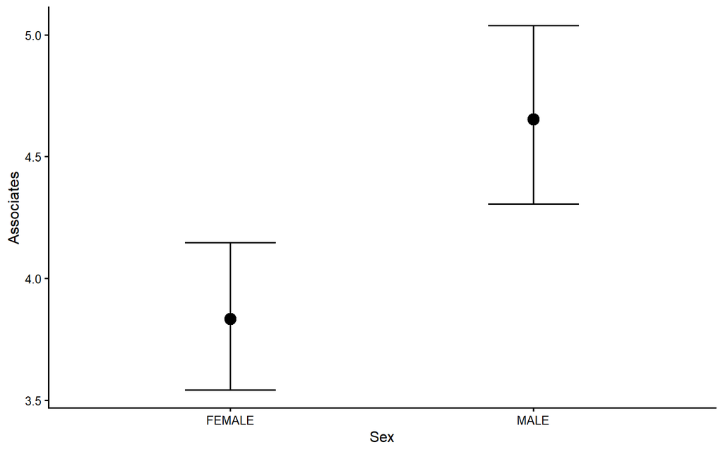

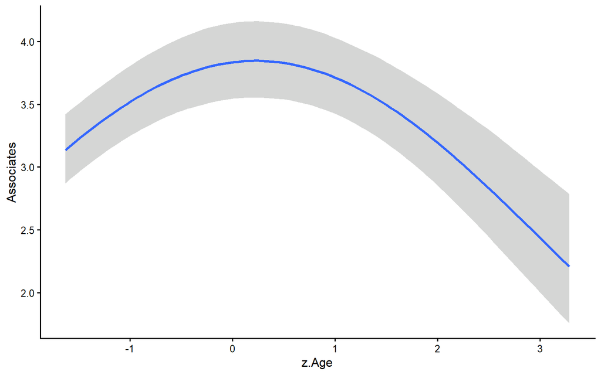

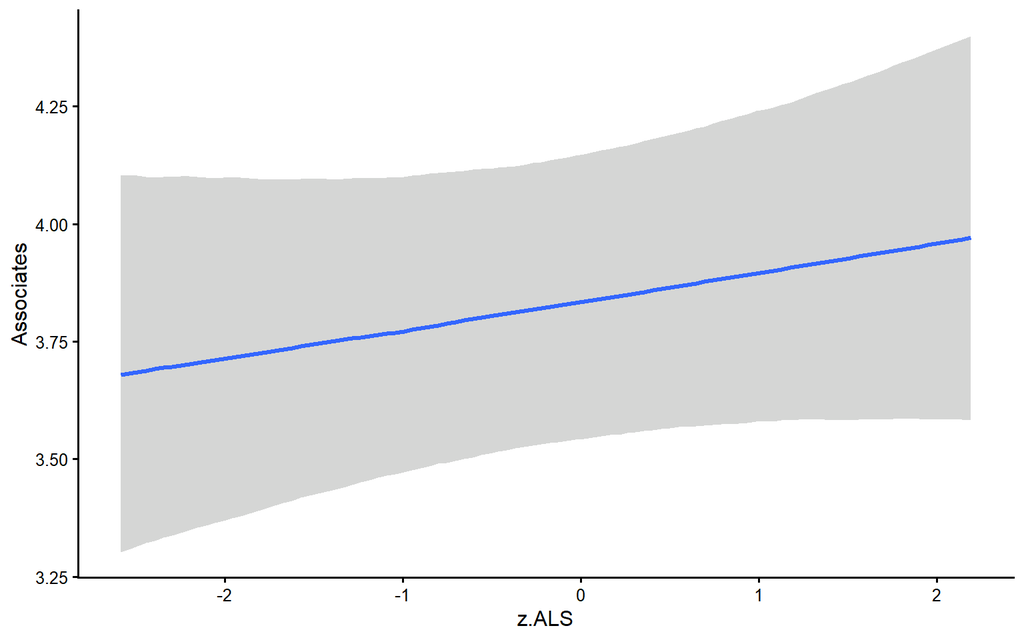

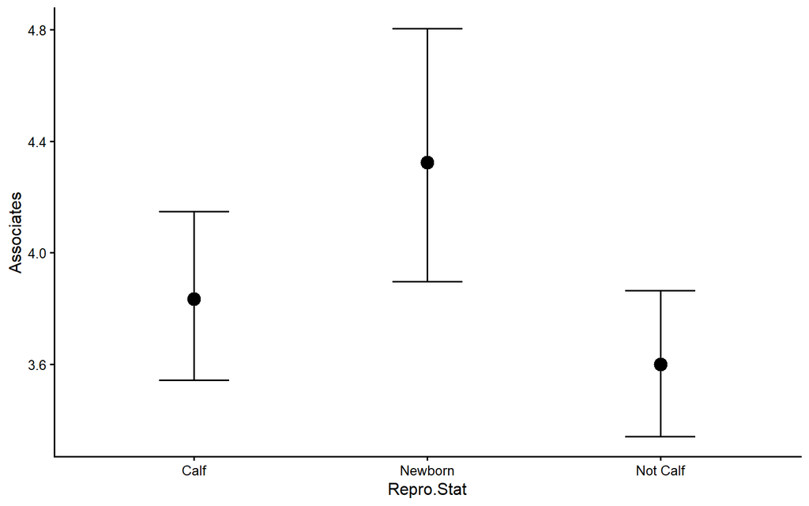

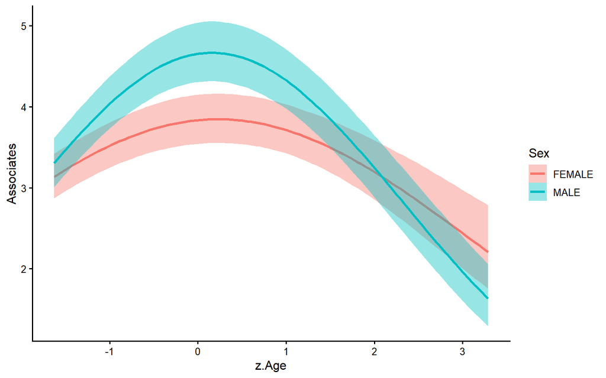

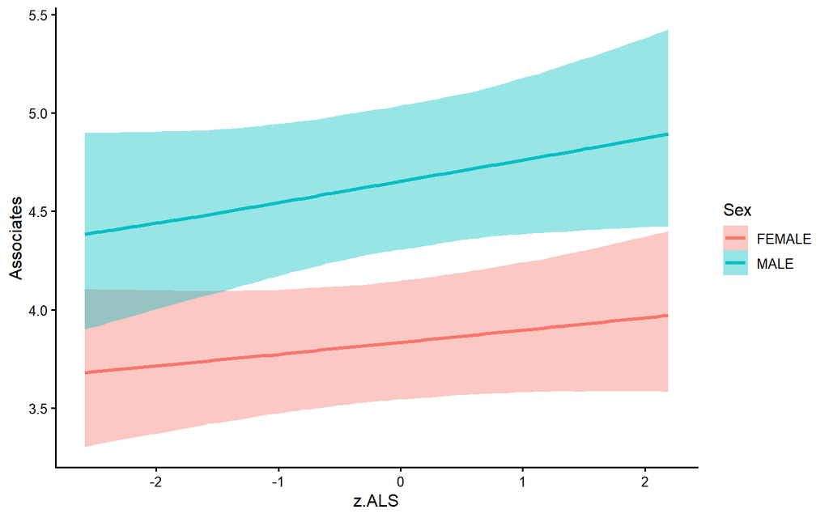

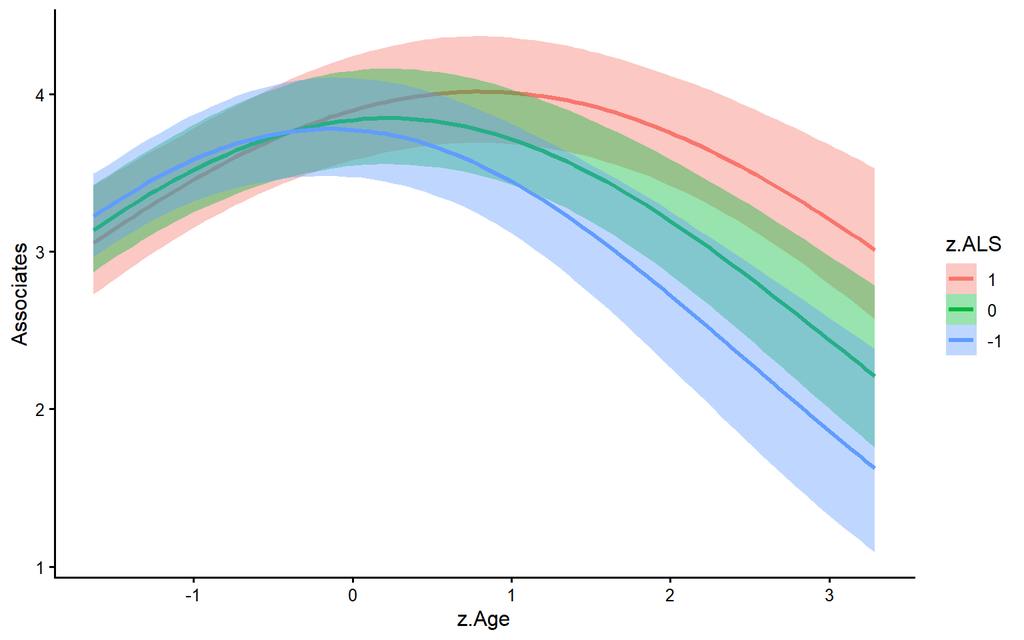

```r
conditional_effects(mod_2)
```

### Loo comparisons

```r
loo_compare(mod_1, mod_2)
```

```
##       elpd_diff se_diff
## mod_2  0.0       0.0
## mod_1 -9.2       6.3
```

## Posterior predictive checks

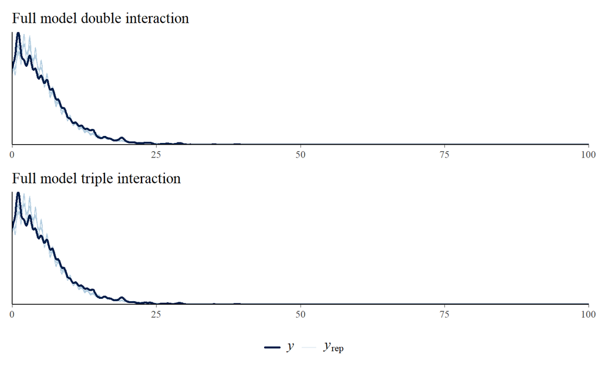

```r
ppc1 <- pp_check(mod_1,
         type = "dens_overlay",
         ndraws = 50) + xlim(0,100) +
  ggtitle('Full model double interaction')

ppc2 <- pp_check(mod_2,
         type = "dens_overlay",
         ndraws = 50) + xlim(0,100)+
  ggtitle('Full model triple interaction')

ppcfig <- (ppc1/ppc2) +
  plot_layout(guides = "collect") &
  theme(legend.position = "bottom")

ppcfig
```

# **Post-Processing**

This section includes extracting and marginalising fixed effects and extracting and organising random effects used in publication figures.

## Variance components

```r
varcomps <- VarCorr(mod_2)
print(varcomps)
```

```
## $Dolphin.ID
## $Dolphin.ID$sd
##                   Estimate   Est.Error       Q2.5      Q97.5
## Intercept        0.1991455 0.009438268  0.1817649  0.2183712
## polyz.Age21     28.0040739 2.310536089 23.7812956 32.7504621
## polyz.Age22      4.0560210 2.392823062  0.2290222  9.1588354
## shape_Intercept  0.7974206 0.037818665  0.7258849  0.8731784
## shape_z.Age      0.5975037 0.037176045  0.5277123  0.6728688
##
## $Dolphin.ID$cor
## , , Intercept
##
##                  Estimate  Est.Error       Q2.5     Q97.5
## Intercept       1.0000000 0.00000000  1.0000000 1.0000000
## polyz.Age21     0.2339106 0.08028623  0.0712547 0.3823484
## polyz.Age22     0.2388989 0.28767405 -0.4408711 0.7278168
## shape_Intercept 0.9278177 0.01790735  0.8898867 0.9597283
## shape_z.Age     0.2289596 0.06920352  0.0867875 0.3599738
##
## , , polyz.Age21
##
##                  Estimate  Est.Error       Q2.5     Q97.5
## Intercept       0.2339106 0.08028623  0.0712547 0.3823484
## polyz.Age21     1.0000000 0.00000000  1.0000000 1.0000000
## polyz.Age22     0.3319417 0.28531293 -0.3368247 0.8046381
## shape_Intercept 0.4142437 0.07393687  0.2625543 0.5532998
## shape_z.Age     0.9590767 0.02249871  0.9061324 0.9920492
##
## , , polyz.Age22
##
##                  Estimate Est.Error       Q2.5     Q97.5
## Intercept       0.2388989 0.2876740 -0.4408711 0.7278168
## polyz.Age21     0.3319417 0.2853129 -0.3368247 0.8046381
## polyz.Age22     1.0000000 0.0000000  1.0000000 1.0000000
## shape_Intercept 0.3256058 0.2902072 -0.3867989 0.7932789
## shape_z.Age     0.3881809 0.2846511 -0.3056956 0.8298505
##
## , , shape_Intercept
##
##                  Estimate  Est.Error       Q2.5     Q97.5
```

[output cut: 116 more lines]

```
## shape_Intercept 1.0000000 0.0000000  1.0000000 1.0000000
##
##
## $Year$cov
## , , Intercept
##
##                   Estimate  Est.Error        Q2.5      Q97.5
## Intercept       0.03192007 0.01023230  0.01686520 0.05633419
## shape_Intercept 0.02223804 0.02934964 -0.03474499 0.08497435
##
## , , shape_Intercept
##
##                   Estimate  Est.Error        Q2.5      Q97.5
## Intercept       0.02223804 0.02934964 -0.03474499 0.08497435
## shape_Intercept 0.59631415 0.18603391  0.32204256 1.05032574
```

## Marginalising fixed effects

First all fixed effects are extracted and marginalised.

```r
## mean.s ##
margins.mean.s <- brmsmargins(mod_2,
                              at = data.frame(Sex = c(1,2)),
                              contrasts = cbind(
                                "AME Female v Male" = c(1,-1)),
                              CI = 0.95,
                              effects = "fixedonly")

margins.mean.s$Summary
```

| M | Mdn | LL | UL | PercentROPE | PercentMID | CI | CIType | ROPE | MID |
| --- | --- | --- | --- | --- | --- | --- | --- | --- | --- |
| 3.547147 | 3.546245 | 3.287678 | 3.797305 | NA | NA | 0.95 | HDI | NA | NA |
| 4.161100 | 4.158201 | 3.858233 | 4.455287 | NA | NA | 0.95 | HDI | NA | NA |

```r
margins.mean.s$ContrastSummary
```

| M | Mdn | LL | UL | PercentROPE | PercentMID | CI | CIType | ROPE | MID | Label |
| --- | --- | --- | --- | --- | --- | --- | --- | --- | --- | --- |
| -0.6139532 | -0.6130404 | -0.784443 | -0.4530702 | NA | NA | 0.95 | HDI | NA | NA | AME Female v Male |

```r
## mean.a ##
h <- 0.001
margins.mean.a <- brmsmargins(mod_2,
                              add = data.frame(z.Age = c(0,0+h)),
                              contrasts = cbind("AME z.Age" = c(-1/h, 1/h)),
                              CI = 0.95,
                              effects = "fixedonly")

margins.mean.a$Summary
```

| M | Mdn | LL | UL | PercentROPE | PercentMID | CI | CIType | ROPE | MID |
| --- | --- | --- | --- | --- | --- | --- | --- | --- | --- |
| 3.845363 | 3.843572 | 3.569953 | 4.098280 | NA | NA | 0.95 | HDI | NA | NA |
| 3.845569 | 3.843767 | 3.570076 | 4.098427 | NA | NA | 0.95 | HDI | NA | NA |

```r
margins.mean.a$ContrastSummary
```

| M | Mdn | LL | UL | PercentROPE | PercentMID | CI | CIType | ROPE | MID | Label |
| --- | --- | --- | --- | --- | --- | --- | --- | --- | --- | --- |
| 0.2062082 | 0.2064157 | 0.1279783 | 0.2908506 | NA | NA | 0.95 | HDI | NA | NA | AME z.Age |

```r
## mean.l ##
h <- 0.001
margins.mean.l <- brmsmargins(mod_2,
                              add = data.frame(z.ALS = c(0,0+h)),
                              contrasts = cbind("AME z.ALS" = c(-1/h, 1/h)),
                              CI = 0.95,
                              effects = "fixedonly")

margins.mean.l$Summary
```

| M | Mdn | LL | UL | PercentROPE | PercentMID | CI | CIType | ROPE | MID |
| --- | --- | --- | --- | --- | --- | --- | --- | --- | --- |
| 3.845363 | 3.843572 | 3.569953 | 4.098280 | NA | NA | 0.95 | HDI | NA | NA |
| 3.845534 | 3.843721 | 3.568570 | 4.096962 | NA | NA | 0.95 | HDI | NA | NA |

```r
margins.mean.l$ContrastSummary
```

| M | Mdn | LL | UL | PercentROPE | PercentMID | CI | CIType | ROPE | MID | Label |
| --- | --- | --- | --- | --- | --- | --- | --- | --- | --- | --- |
| 0.1708085 | 0.1700072 | 0.08264748 | 0.2699509 | NA | NA | 0.95 | HDI | NA | NA | AME z.ALS |

```r
## mean.r ##
margins.mean.r <- brmsmargins(mod_2,
                              at = data.frame(
                                Repro.Stat = factor(1:3,
                                                    labels = c("Newborn", "Calf", "Not Calf"))),
                              contrasts = cbind(
                                "AME Newborn v Calf" = c(1,-1,0),
                                "AME Newborn v Not Calf" = c(1,0,-1),
                                "AME Calf v Not Calf" = c(0,1,-1)),
                              CI = 0.95,
                              effects = "fixedonly")

margins.mean.r$Summary
```

| M | Mdn | LL | UL | PercentROPE | PercentMID | CI | CIType | ROPE | MID |
| --- | --- | --- | --- | --- | --- | --- | --- | --- | --- |
| 4.587999 | 4.583467 | 4.127535 | 5.034977 | NA | NA | 0.95 | HDI | NA | NA |
| 4.066691 | 4.063566 | 3.765663 | 4.359497 | NA | NA | 0.95 | HDI | NA | NA |
| 3.815178 | 3.813010 | 3.544561 | 4.069774 | NA | NA | 0.95 | HDI | NA | NA |

```r
margins.mean.r$ContrastSummary
```

| M | Mdn | LL | UL | PercentROPE | PercentMID | CI | CIType | ROPE | MID | Label |
| --- | --- | --- | --- | --- | --- | --- | --- | --- | --- | --- |
| 0.5213073 | 0.5179644 | 0.2024418 | 0.8576323 | NA | NA | 0.95 | HDI | NA | NA | AME Newborn v Calf |
| 0.7728200 | 0.7677697 | 0.4272216 | 1.1310254 | NA | NA | 0.95 | HDI | NA | NA | AME Newborn v Not Calf |
| 0.2515127 | 0.2509731 | 0.1349236 | 0.3689625 | NA | NA | 0.95 | HDI | NA | NA | AME Calf v Not Calf |

```r
## disp.s ##
margins.disp.s <- brmsmargins(mod_2,
                              at = data.frame(Sex = c(1,2)),
                              contrasts = cbind(
                                "AME Female v Male" = c(1,-1)),
                              dpar = "shape",
                              backtrans = "linear",
                              CI = 0.95,
                              effects = "fixedonly")

margins.disp.s$Summary
```

| M | Mdn | LL | UL | PercentROPE | PercentMID | CI | CIType | ROPE | MID |
| --- | --- | --- | --- | --- | --- | --- | --- | --- | --- |
| 2.473299 | 2.472591 | 2.172157 | 2.765911 | NA | NA | 0.95 | HDI | NA | NA |
| 3.060780 | 3.062476 | 2.747002 | 3.356221 | NA | NA | 0.95 | HDI | NA | NA |

```r
margins.disp.s$ContrastSummary
```

| M | Mdn | LL | UL | PercentROPE | PercentMID | CI | CIType | ROPE | MID | Label |
| --- | --- | --- | --- | --- | --- | --- | --- | --- | --- | --- |
| -0.5874817 | -0.5869905 | -0.7539719 | -0.4148225 | NA | NA | 0.95 | HDI | NA | NA | AME Female v Male |

```r
## disp.a ##
margins.disp.a <- brmsmargins(mod_1,
                              add = data.frame(z.Age = c(0,h)),
                              contrasts = cbind("AME z.Age" = c(-1/h, 1/h)),
                              dpar = "shape",
                              backtrans = "linear",
                              CI = 0.95,
                              effects = "fixedonly")

margins.disp.a$Summary
```

| M | Mdn | LL | UL | PercentROPE | PercentMID | CI | CIType | ROPE | MID |
| --- | --- | --- | --- | --- | --- | --- | --- | --- | --- |
| 2.707271 | 2.706627 | 2.437185 | 3.005061 | NA | NA | 0.95 | HDI | NA | NA |
| 2.707330 | 2.706702 | 2.437237 | 3.005167 | NA | NA | 0.95 | HDI | NA | NA |

```r
margins.disp.a$ContrastSummary
```

| M | Mdn | LL | UL | PercentROPE | PercentMID | CI | CIType | ROPE | MID | Label |
| --- | --- | --- | --- | --- | --- | --- | --- | --- | --- | --- |
| 0.0589115 | 0.05616913 | 0.0282649 | 0.09382323 | NA | NA | 0.95 | HDI | NA | NA | AME z.Age |

```r
## disp.l ##
h <- 0.001
margins.disp.l <- brmsmargins(mod_2,
                              add = data.frame(z.ALS = c(0,0+h)),
                              contrasts = cbind("AME z.ALS" = c(-1/h, 1/h)),
                              dpar = "shape",
                              backtrans = "linear",
                              CI = 0.95,
                              effects = "fixedonly")

margins.disp.l$Summary
```

| M | Mdn | LL | UL | PercentROPE | PercentMID | CI | CIType | ROPE | MID |
| --- | --- | --- | --- | --- | --- | --- | --- | --- | --- |
| 2.764848 | 2.766820 | 2.466868 | 3.049424 | NA | NA | 0.95 | HDI | NA | NA |
| 2.764992 | 2.766951 | 2.489367 | 3.071965 | NA | NA | 0.95 | HDI | NA | NA |

```r
margins.disp.l$ContrastSummary
```

| M | Mdn | LL | UL | PercentROPE | PercentMID | CI | CIType | ROPE | MID | Label |
| --- | --- | --- | --- | --- | --- | --- | --- | --- | --- | --- |
| 0.1440231 | 0.1421529 | 0.09005684 | 0.2000106 | NA | NA | 0.95 | HDI | NA | NA | AME z.ALS |

```r
## disp.r ##
margins.disp.r <- brmsmargins(mod_2,
                              at = data.frame(
                                Repro.Stat = factor(1:3,
                                                    labels = c("Newborn", "Calf", "Not Calf"))),
                              contrasts = cbind(
                                "AME Newborn v Calf" = c(1,-1,0),
                                "AME Newborn v Not Calf" = c(1,0,-1),
                                "AME Calf v Not Calf" = c(0,1,-1)),
                              dpar = "shape",
                              backtrans = "linear",
                              CI = 0.95,
                              effects = "fixedonly")

margins.disp.r$Summary
```

| M | Mdn | LL | UL | PercentROPE | PercentMID | CI | CIType | ROPE | MID |
| --- | --- | --- | --- | --- | --- | --- | --- | --- | --- |
| 3.183009 | 3.153458 | 2.654008 | 3.763380 | NA | NA | 0.95 | HDI | NA | NA |
| 2.706952 | 2.707115 | 2.414209 | 2.997218 | NA | NA | 0.95 | HDI | NA | NA |
| 2.772000 | 2.773368 | 2.495088 | 3.076587 | NA | NA | 0.95 | HDI | NA | NA |

```r
margins.disp.r$ContrastSummary
```

| M | Mdn | LL | UL | PercentROPE | PercentMID | CI | CIType | ROPE | MID | Label |
| --- | --- | --- | --- | --- | --- | --- | --- | --- | --- | --- |
| 0.47605621 | 0.43666666 | 0.080687233 | 0.95530796 | NA | NA | 0.95 | HDI | NA | NA | AME Newborn v Calf |
| 0.41100826 | 0.37170128 | 0.005579545 | 0.88573588 | NA | NA | 0.95 | HDI | NA | NA | AME Newborn v Not Calf |
| -0.06504794 | -0.06253485 | -0.102794519 | -0.02904344 | NA | NA | 0.95 | HDI | NA | NA | AME Calf v Not Calf |

Then we create tables out of these extracted effects

```r
# this is the conversions for fixed effects
# mean s
posterior.mean.s <- as.data.frame(margins.mean.s$Posterior)
colnames(posterior.mean.s) <- c("Female", "Male")

posterior.mean.s <- posterior.mean.s %>%
  melt()

posterior.mean.s <- posterior.mean.s %>%
  mutate(component = "Mean") %>%
  mutate(effect = "Sex")

# mean a
posterior.mean.a <- as.data.frame(margins.mean.a$Posterior) %>%
  select(V1) %>%
  rename(value = V1) %>%
  mutate(component = "Mean")%>%
  mutate(variable = "Age") %>%
  mutate(effect = "Age")

# mean l
posterior.mean.l <- as.data.frame(margins.mean.l$Posterior) %>%
  select(V1) %>%
  rename(value = V1) %>%
  mutate(component = "Mean")%>%
  mutate(variable = "ALS") %>%
  mutate(effect = "ALS")

# mean r
posterior.mean.r <- as.data.frame(margins.mean.r$Posterior)
colnames(posterior.mean.r) <- c("Newborn", "Calf", "Not Calf")

posterior.mean.r <- posterior.mean.r %>%
  melt()

posterior.mean.r <- posterior.mean.r %>%
  mutate(component = "Mean") %>%
  mutate(effect = "Reproductive State")
```

```r
# this is the conversions for fixed effects
# disp s #
posterior.disp.s <- as.data.frame(margins.disp.s$Posterior)
colnames(posterior.disp.s) <- c("Female", "Male")

posterior.disp.s <- posterior.disp.s %>%
  melt()

posterior.disp.s <- posterior.disp.s %>%
  mutate(component = "Dispersion") %>%
  mutate(effect = "Sex")

# disp a #
posterior.disp.a <- as.data.frame(margins.disp.a$Posterior) %>%
  select(V1) %>%
  rename(value = V1) %>%
  mutate(component = "Dispersion") %>%
  mutate(variable = "Age") %>%
  mutate(effect = "Age")

# disp l
posterior.disp.l <- as.data.frame(margins.disp.l$Posterior) %>%
  select(V1) %>%
  rename(value = V1) %>%
  mutate(component = "Dispersion")%>%
  mutate(variable = "ALS") %>%
  mutate(effect = "ALS")

# disp r
posterior.disp.r <- as.data.frame(margins.disp.r$Posterior)
colnames(posterior.disp.r) <- c("Newborn", "Calf", "Not Calf")

posterior.disp.r <- posterior.disp.r %>%
  melt()

posterior.disp.r <- posterior.disp.r %>%
  mutate(component = "Dispersion") %>%
  mutate(effect = "Reproductive State")
```

After fixed effects, random effects are extracted.

```r
# note: because these are random effects, i can't use brmsmargins to backtransform
# dispersion components, so instead they are extracted using asdrawsmatrix and
# exponent-ed to convert back to "latent" scale (which is still log, just not double logged)

## mean portion ##
mean.intercept <- as.data.frame(as_draws_matrix(mod_2))$"b_Intercept"
mean(mean.intercept);HPDinterval(as.mcmc(mean.intercept),0.095)
```

```
## [1] 1.284913
```

```
##         lower    upper
## var1 1.276526 1.285558
## attr(,"Probability")
## [1] 0.095
```

```r
mean.year <- as.data.frame(as_draws_matrix(mod_2))$"sd_Year__Intercept"
mean(mean.year);HPDinterval(as.mcmc(mean.year),0.095)
```

```
## [1] 0.176535
```

```
##          lower     upper
## var1 0.1682903 0.1742847
## attr(,"Probability")
## [1] 0.095
```

```r
mean.date <- as.data.frame(as_draws_matrix(mod_2))$"sd_Observation.Date__Intercept"
mean(mean.date);HPDinterval(as.mcmc(mean.date),0.095)
```

```
## [1] 0.6208733
```

```
##          lower     upper
## var1 0.6192858 0.6214717
## attr(,"Probability")
## [1] 0.095
```

```r
mean.id <- as.data.frame(as_draws_matrix(mod_2))$"sd_Dolphin.ID__Intercept"
mean(mean.id);HPDinterval(as.mcmc(mean.id),0.095)
```

```
## [1] 0.1991455
```

```
##          lower     upper
## var1 0.1968553 0.1989628
## attr(,"Probability")
## [1] 0.095
```

```r
## dispersion portion
disp.intercept <- exp(as.data.frame(as_draws_matrix(mod_2))$"b_shape_Intercept")
mean(disp.intercept);HPDinterval(as.mcmc(disp.intercept),0.95)
```

```
## [1] 10.95367
```

```
##         lower   upper
## var1 7.697509 14.1671
## attr(,"Probability")
## [1] 0.95
```

```r
disp.year <- exp(as.data.frame(as_draws_matrix(mod_2))$"sd_Year__shape_Intercept")
mean(disp.year);HPDinterval(as.mcmc(disp.year),0.095)
```

```
## [1] 2.1605
```

```
##         lower    upper
## var1 2.005998 2.054907
## attr(,"Probability")
## [1] 0.095
```

```r
disp.date <- exp(as.data.frame(as_draws_matrix(mod_2))$"sd_Observation.Date__shape_Intercept")
mean(disp.date);HPDinterval(as.mcmc(disp.date),0.095)
```

```
## [1] 4.781889
```

```
##        lower    upper
## var1 4.75573 4.808806
## attr(,"Probability")
## [1] 0.095
```

```r
disp.id <- exp(as.data.frame(as_draws_matrix(mod_2))$"sd_Dolphin.ID__shape_Intercept")
mean(disp.id);HPDinterval(as.mcmc(disp.id),0.095)
```

```
## [1] 2.221398
```

```
##         lower    upper
## var1 2.161736 2.181565
## attr(,"Probability")
## [1] 0.095
```

Next, extracted effects are turned into operable tables.

```r
## mean portion ##
mean.intercept <- as.data.frame(mean.intercept) %>%
  mutate(component = "Mean") %>%
  mutate(effect = "Intercept") %>%
  mutate(variable = "Intercept") %>%
  rename(value = mean.intercept)

mean.year <- as.data.frame(mean.year) %>%
  mutate(component = "Mean") %>%
  mutate(effect = "Random") %>%
  mutate(variable = "Year") %>%
  rename(value = mean.year)

mean.date <- as.data.frame(mean.date) %>%
  mutate(component = "Mean") %>%
  mutate(effect = "Random") %>%
  mutate(variable = "Observation Date") %>%
  rename(value = mean.date)

mean.id <- as.data.frame(mean.id) %>%
  mutate(component = "Mean") %>%
  mutate(effect = "Random") %>%
  mutate(variable = "Individual") %>%
  rename(value = mean.id)
```

```r
## dispersion portion ##
disp.intercept <- as.data.frame(disp.intercept) %>%
  mutate(component = "Dispersion") %>%
  mutate(effect = "Intercept") %>%
  mutate(variable = "Intercept") %>%
  rename(value = disp.intercept)

disp.year <- as.data.frame(disp.year) %>%
  mutate(component = "Dispersion") %>%
  mutate(effect = "Random") %>%
  mutate(variable = "Year") %>%
  rename(value = disp.year)

disp.date <- as.data.frame(disp.date) %>%
  mutate(component = "Dispersion") %>%
  mutate(effect = "Random") %>%
  mutate(variable = "Observation Date") %>%
  rename(value = disp.date)

disp.id <- as.data.frame(disp.id) %>%
  mutate(component = "Dispersion") %>%
  mutate(effect = "Random") %>%
  mutate(variable = "Individual") %>%
  rename(value = disp.id)
```

All extracts are combined together into a data table. These data inform Table 3 and Table S3

```r
# these have been saved to the "margins" folder
mean.margins <- bind_rows(posterior.mean.s, posterior.mean.a, posterior.mean.l, posterior.mean.r, mean.intercept, mean.year,
                          mean.date, mean.id)
disp.margins <- bind_rows(posterior.disp.s, posterior.disp.a, posterior.disp.l, posterior.disp.r, disp.intercept, disp.year,
                          disp.date, disp.id)
allmargins <- rbind(mean.margins, disp.margins)

write.csv(allmargins, "margins/allmargins.csv", row.names = FALSE)
write.csv(mean.margins, "margins/meanmargins.csv", row.names = FALSE)
write.csv(disp.margins, "margins/dispmargins.csv", row.names = FALSE)
```

```r
head(allmargins, 10)
```

|  | variable | value | component | effect |
| --- | --- | --- | --- | --- |
| 1 | Female | 3.757140 | Mean | Sex |
| 2 | Female | 3.761718 | Mean | Sex |
| 3 | Female | 3.643365 | Mean | Sex |
| 4 | Female | 3.477868 | Mean | Sex |
| 5 | Female | 3.447409 | Mean | Sex |
| 6 | Female | 3.467546 | Mean | Sex |
| 7 | Female | 3.563233 | Mean | Sex |
| 8 | Female | 3.458572 | Mean | Sex |
| 9 | Female | 3.319629 | Mean | Sex |
| 10 | Female | 3.409267 | Mean | Sex |

# **Figures**

## Figure 1: Concept Graphs

### Personality

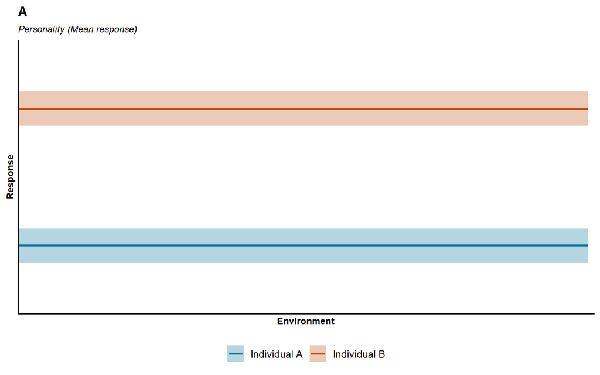

```r
df_personality <- data.frame(
  x = seq(0,10, length.out = 10),
  y = rep(c(3,5), each = 10),
  z = rep(c(2.75,4.75), each = 10),
  z2 = rep(c(3.25,5.25), each = 10),
  i = rep(c("Individual A", "Individual B"), each = 10)
)

personalityconcept <- ggplot(df_personality,
                             aes(x = x,
                                 y = y,
                                 fill = i)) +
  scale_fill_manual(values = c("#0B76A0", "#C04F15")) +
  scale_colour_manual(values = c("#0B76A0", "#C04F15")) +
  geom_ribbon(aes(ymin = z, ymax = z2),
              alpha = 0.3,
              linetype = 'blank') +
  geom_line(aes(colour = i),linewidth = 1) +
  scale_x_continuous(expand = expansion(mult = 0),
                     limits = c(0,10.1)) +
  scale_y_continuous(expand = expansion(mult = 0),
                     limits = c(2,6)) +
  labs(x = "Environment", y = "Response") +
  ggtitle('A', subtitle = "Personality (Mean response)") +
  theme(panel.background = element_rect(fill = "transparent",
                                        linetype = 0),
        plot.background = element_rect(fill = "transparent",
                                       color = NA),
        panel.grid.major = element_blank(),
        panel.grid.minor = element_blank(),
        axis.line = element_line(colour = "black")) +
  theme(plot.title = element_text(face = "bold",
                                  size = 13),
        plot.subtitle = element_text(face = "italic",
                                     size = 9),
        axis.title = element_text(face = "bold",
                                  size = 9,
                                  colour = "black"),
        axis.text = element_blank(),
        axis.ticks = element_blank(),
        text = element_text(family = "sans")) +
  theme(legend.title=element_blank(),
        legend.position = "bottom")

a <- personalityconcept

a
```

### Plasticity

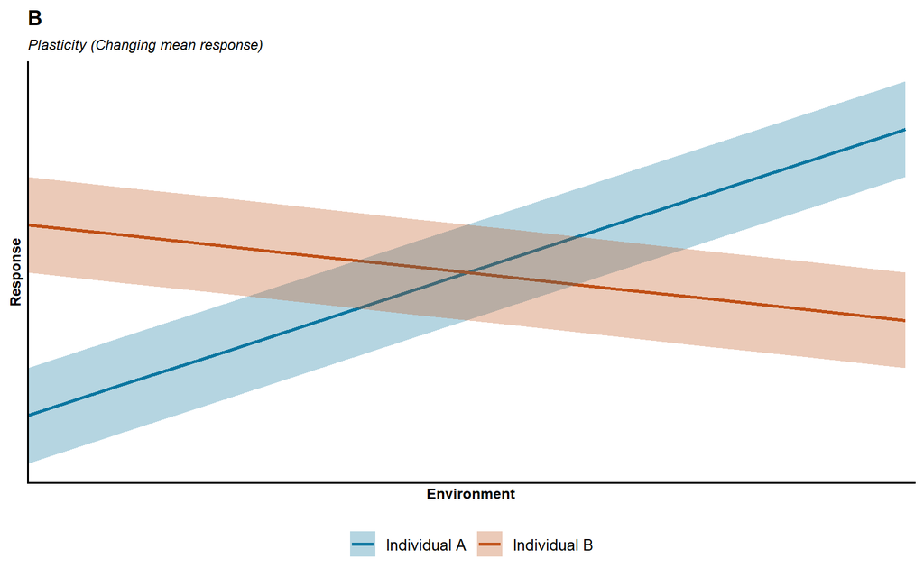

```r
df_p1 <- data.frame(
   x = seq(0,10, length.out = 10),
   y = seq(3,6, length.out = 10),
   sd = rep(0.5, each = 10),
   i = rep(c("Individual A"), each = 10))

df_p2 <- data.frame(
   x = seq(0,10, length.out = 10),
   y = seq(5,4, length.out = 10),
   sd = rep(0.5, each = 10),
   i = rep(c("Individual B"), each = 10))

df_plasticity <- rbind(df_p1, df_p2)

plasticityconcept <- ggplot(df_plasticity,
                             aes(x = x,
                                 y = y,
                                 fill = i)) +
  scale_fill_manual(values = c("#0B76A0", "#C04F15")) +
  scale_colour_manual(values = c("#0B76A0", "#C04F15")) +
  geom_line(aes(color = i),linewidth = 1) +
  geom_ribbon(aes(ymin = y-sd, ymax = y+sd),
              alpha = 0.3,
              linetype = 'blank') +
  scale_x_continuous(expand = expansion(mult = 0),
                     limits = c(0,10.1)) +
  labs(x = "Environment", y = "Response") +
  ggtitle('B', subtitle = "Plasticity (Changing mean response)") +
  theme(panel.background = element_rect(fill = "transparent",
                                        linetype = 0),
        plot.background = element_rect(fill = "transparent",
                                       color = NA),
        panel.grid.major = element_blank(),
        panel.grid.minor = element_blank(),
        axis.line = element_line(colour = "black")) +
  theme(plot.title = element_text(face = "bold",
                                  size = 13),
        plot.subtitle = element_text(face = "italic",
                                     size = 9),
        axis.title = element_text(face = "bold",
                                  size = 9,
                                  colour = "black"),
        axis.text = element_blank(),
        axis.ticks = element_blank(),
        text = element_text(family = "sans")) +
  theme(legend.title=element_blank(),
        legend.position = "bottom")

b <- plasticityconcept

b
```

### Predictability

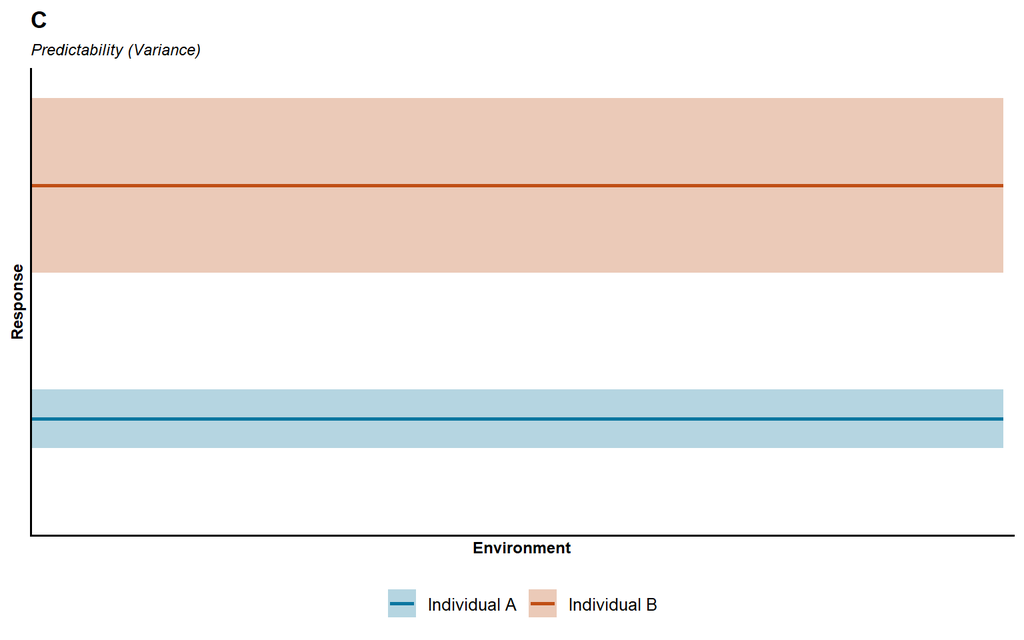

```r
df_predictability <- data.frame(
  x = seq(0,10, length.out = 10),
  y = rep(c(3,5), each = 10),
  z = rep(c(2.75,4.25), each = 10),
  z2 = rep(c(3.25,5.75), each = 10),
  i = rep(c("Individual A", "Individual B"), each = 10)
)

predictabilityconcept <- ggplot(df_predictability,
                             aes(x = x,
                                 y = y,
                                 fill = i)) +
  scale_fill_manual(values = c("#0B76A0", "#C04F15")) +
  scale_colour_manual(values = c("#0B76A0", "#C04F15")) +
  geom_ribbon(aes(ymin = z, ymax = z2),
              alpha = 0.3,
              linetype = 'blank') +
  geom_line(aes(colour = i),linewidth = 1) +
  scale_x_continuous(expand = expansion(mult = 0),
                     limits = c(0,10.1)) +
  scale_y_continuous(expand = expansion(mult = 0),
                     limits = c(2,6)) +
  labs(x = "Environment", y = "Response") +
  ggtitle('C', subtitle = "Predictability (Variance)") +
  theme(panel.background = element_rect(fill = "transparent",
                                        linetype = 0),
        plot.background = element_rect(fill = "transparent",
                                       color = NA),
        panel.grid.major = element_blank(),
        panel.grid.minor = element_blank(),
        axis.line = element_line(colour = "black")) +
  theme(plot.title = element_text(face = "bold",
                                  size = 13),
        plot.subtitle = element_text(face = "italic",
                                     size = 9),
        axis.title = element_text(face = "bold",
                                  size = 9,
                                  colour = "black"),
        axis.text = element_blank(),
        axis.ticks = element_blank(),
        text = element_text(family = "sans")) +
  theme(legend.title=element_blank(),
        legend.position = "bottom")


c <- predictabilityconcept

c
```

### Malleability

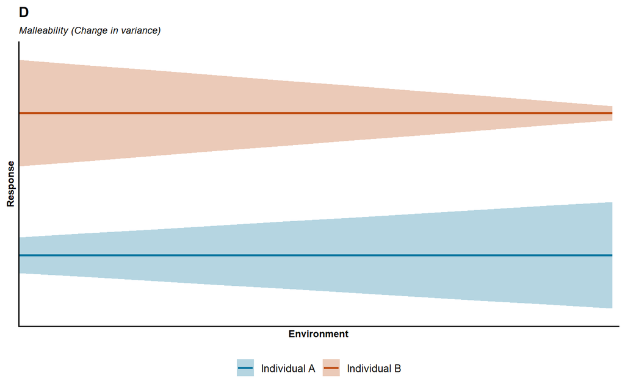

```r
df_m1 <- data.frame(
   x = seq(0,10, length.out = 10),
   y = rep(3, length.out = 10),
   sd = seq(0.25,0.75, length.out = 10),
   i = rep(c("Individual A"), each = 10))

df_m2 <- data.frame(
   x = seq(0,10, length.out = 10),
   y = rep(5, length.out = 10),
   sd = seq(0.75,0.1, length.out = 10),
   i = rep(c("Individual B"), each = 10))

df_malleable = rbind(df_m1, df_m2)

malleabilityconcept <- ggplot(df_malleable,
                             aes(x = x,
                                 y = y,
                                 fill = i)) +
  scale_fill_manual(values = c("#0B76A0", "#C04F15")) +
  scale_colour_manual(values = c("#0B76A0", "#C04F15")) +
  geom_ribbon(aes(ymin = y-sd, ymax = y+sd),
              alpha = 0.3,
              linetype = 'blank') +
  geom_line(aes(colour = i),linewidth = 1) +
  scale_x_continuous(expand = expansion(mult = 0),
                     limits = c(0,10.1)) +
  scale_y_continuous(expand = expansion(mult = 0),
                     limits = c(2,6)) +
  labs(x = "Environment", y = "Response") +
  ggtitle('D', subtitle = "Malleability (Change in variance)") +
  theme(panel.background = element_rect(fill = "transparent",
                                        linetype = 0),
        plot.background = element_rect(fill = "transparent",
                                       color = NA),
        panel.grid.major = element_blank(),
        panel.grid.minor = element_blank(),
        axis.line = element_line(colour = "black")) +
  theme(plot.title = element_text(face = "bold",
                                  size = 13),
        plot.subtitle = element_text(face = "italic",
                                     size = 9),
        axis.title = element_text(face = "bold",
                                  size = 9,
                                  colour = "black"),
        axis.text = element_blank(),
        axis.ticks = element_blank(),
        text = element_text(family = "sans")) +
  theme(legend.title=element_blank(),
        legend.position = "bottom")

d <- malleabilityconcept

d
```

### Plasticity and Malleability

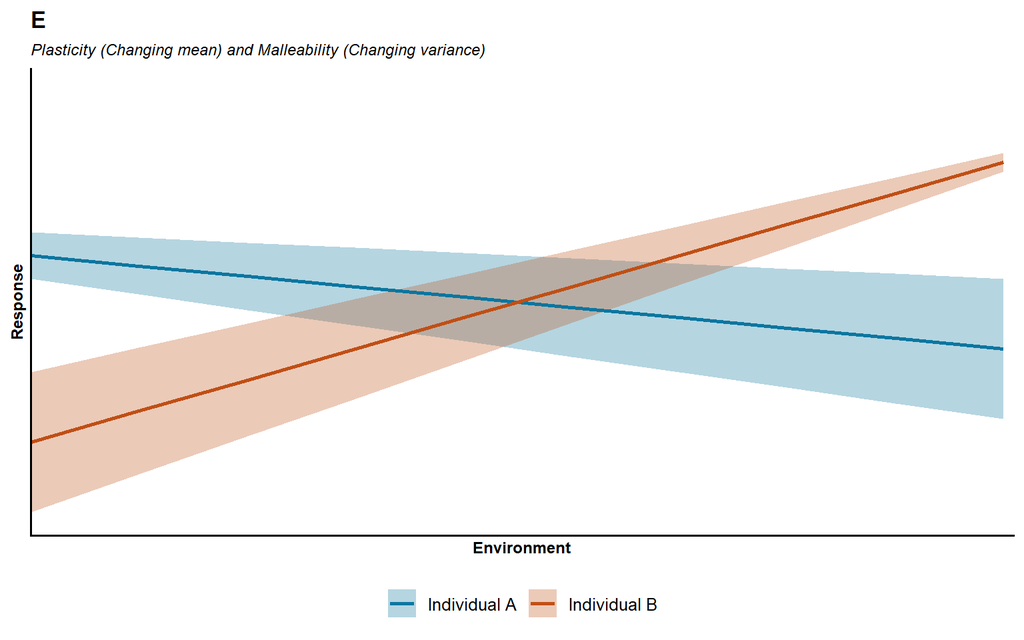

```r
df_pm1 <- data.frame(
   x = seq(0,10, length.out = 10),
   y = seq(5,4, length.out = 10),
   sd = seq(0.25,0.75, length.out = 10),
   i = rep(c("Individual A"), each = 10))

df_pm2 <- data.frame(
   x = seq(0,10, length.out = 10),
   y = seq(3,6, length.out = 10),
   sd = seq(0.75,0.1, length.out = 10),
   i = rep(c("Individual B"), each = 10))

df_predmal <- rbind(df_pm1, df_pm2)

predmalconcept <- ggplot(df_predmal,
                             aes(x = x,
                                 y = y,
                                 fill = i)) +
  scale_fill_manual(values = c("#0B76A0", "#C04F15")) +
  scale_colour_manual(values = c("#0B76A0", "#C04F15")) +
  geom_ribbon(aes(ymin = y-sd, ymax = y+sd),
              alpha = 0.3,
              linetype = 'blank') +
  geom_line(aes(colour = i),linewidth = 1) +
  scale_x_continuous(expand = expansion(mult = 0),
                     limits = c(0,10.1)) +
  scale_y_continuous(expand = expansion(mult = 0),
                     limits = c(2,7)) +
  labs(x = "Environment", y = "Response") +
  ggtitle('E', subtitle = "Plasticity (Changing mean) and Malleability (Changing variance)") +
  theme(panel.background = element_rect(fill = "transparent",
                                        linetype = 0),
        plot.background = element_rect(fill = "transparent",
                                       color = NA),
        panel.grid.major = element_blank(),
        panel.grid.minor = element_blank(),
        axis.line = element_line(colour = "black")) +
  theme(plot.title = element_text(face = "bold",
                                  size = 13),
        plot.subtitle = element_text(face = "italic",
                                     size = 9),
        axis.title = element_text(face = "bold",
                                  size = 9,
                                  colour = "black"),
        axis.text = element_blank(),
        axis.ticks = element_blank(),
        text = element_text(family = "sans")) +
  theme(legend.title=element_blank(),
        legend.position = "bottom")

e <- predmalconcept

e
```

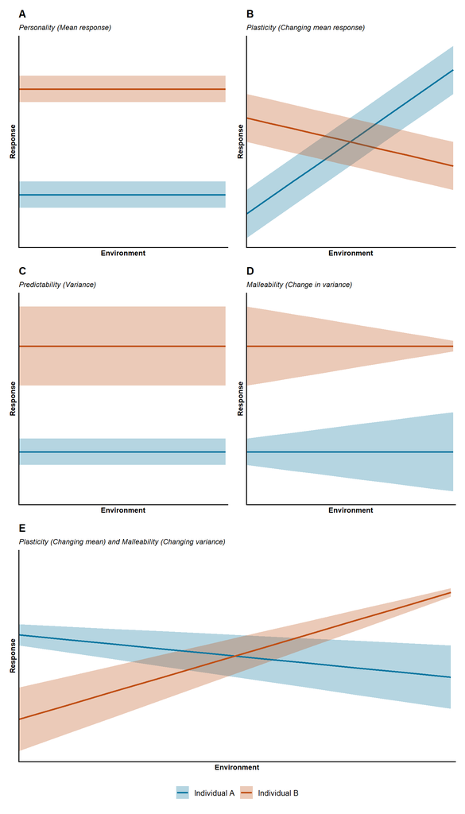

```r
figure1 <- (a + theme(legend.position = "hidden")|b + theme(legend.position = "hidden"))/
  (c + theme(legend.position = "hidden")|d + theme(legend.position = "hidden"))/e

figure1
```

```r
#ggsave(figure1, filename = here("figures", "Fig1.tiff"), bg = "transparent", device = 'tiff', height = 20, width = 15, units = "cm", dpi = 300, compression = "lzw")
```

## Figure 2

### Figure 2A (Full model)

First, we create predictions for the full model using epred and linpred draws.

```r
# needed to unscale z.Age
m = mean(dat$ObsAge)
s <- sd(dat$ObsAge)

# needed to unscale ALS
m_als <- mean(dat$ALS)
s_als <- sd(dat$ALS)

#create new sequence of data to predict on from the model
ageseq <- seq_range(dat$z.Age, n = 53)
alsseq <- seq_range(dat$z.ALS, n = 7, expand = 0.4)
alsseq <- alsseq[-c(1,7)] #remove the extension on the left to set initial ALS cap fairly close to weaning age (~3.7yo)

newdat <- expand.grid(
  z.Age = ageseq,
  z.ALS = alsseq,
  Repro.Stat = NA,
  Sex = c("FEMALE", "MALE"))

# unscale z.Age in new dataset
newdat <- newdat %>%
  mutate(Age = ((z.Age * s) + m)) %>%
  mutate(ALS = ((z.ALS * s_als) + m_als))

# draw epred -- or expectation of the posterior, i.e E(yi) of the model formula
mean_draws <- mod_2 %>%
  epred_draws(newdata = newdat,
              re_formula = NA) %>%
  group_by(Sex, Age, ALS, .draw) %>%
  summarise(Age = mean(Age),
            ALS = mean(ALS),
            predicted = mean(.epred))

mean_draws <- mean_draws %>%
  filter(Age <= ALS) %>%
  mutate(alsbins = ALS/365) %>%
  mutate(alsbins = as.factor(alsbins))

#now repeat with dispersion components
disp_draws <- mod_2  %>%
  linpred_draws(newdata = newdat,
                dpar = "shape",
                transform = TRUE,
                re_formula = NA) %>%
  group_by(Sex, Age, ALS, .draw) %>%
  summarise(Age = mean(Age),
            ALS = mean(ALS),
            predicted = mean(.linpred),
            shape = mean(shape))

 disp_draws <- disp_draws %>%
  filter(Age <= ALS) %>%
  mutate(alsbins = ALS/365) %>%
  mutate(alsbins = as.factor(alsbins))

#write.csv(mean_draws, "data/fig2_a_draws.csv", row.names = FALSE)
#write.csv(disp_draws, "data/fig2_d_draws.csv", row.names = FALSE)

#to import, use the following (requires "here" package)
# mean_draws <- read.csv(here("FILEFOLDERNAME", "fig2_a_draws.csv"), header = TRUE, sep = ",")
# disp_draws <- read.csv(here("FILEFOLDERNAME", "fig2_d_draws.csv"), header = TRUE, sep = ",")
```

Then, we can utilise those draws to create graphs.

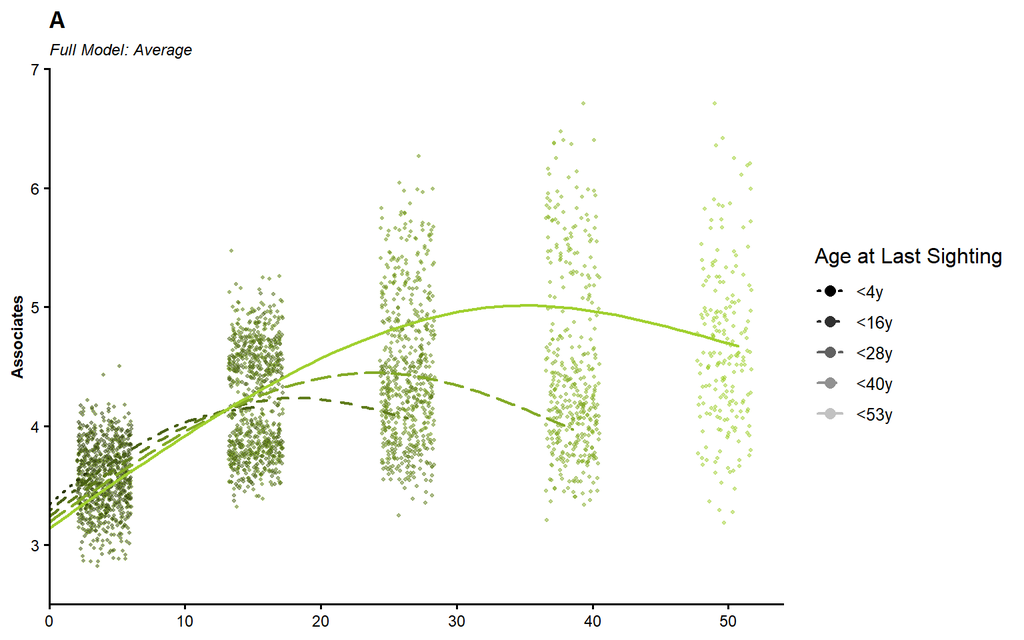

```r
# mean response level

# prep data by fixing bins
levels(mean_draws$alsbins) <- c("<4y", "<16y", "<28y", "<40y", "<53y")

# set breaks for jittered points
# slightly offset from geom lines for visual balance
agebreaks = mean_draws %>%
  filter(Age == c("1481","5553.75","9626.49999999999","14069.5","18142.25"))

mean.cols <- c("<4y" = "#2D3A0D",
               "<16y" = "#496016",
               "<28y" = "#607D1C",
               "<40y" = "#83AA27",
               "<53y" = "#A0D02F")

# plot code
meanage <- ggplot(mean_draws,
                   aes(x = Age/365,
                       y = predicted,
                       colour = alsbins)) +
  geom_jitter(data = slice_sample(agebreaks, n = 100),
              aes(fill = as.factor(Age)),
              size = 1,
              alpha = 0.5,
              width = 2,
              shape = 21,
              stroke = 0,
              show.legend = TRUE) +
  geom_smooth(aes(linetype = alsbins),
              linewidth = 0.75, lineend = "round",
              method = "gam", formula = y ~ s(x, bs = "cs", k = 4), se = FALSE, show.legend = TRUE) +
  scale_colour_manual(values = mean.cols,
                      labels = c("<4y", "<16y", "<28y", "<40y", "<53y")) +
  scale_fill_manual(values = c("#2D3A0D", "#496016", "#607D1C", "#83AA27", "#A0D02F"),
                    labels = c("<4y", "<16y", "<28y", "<40y", "<53y")) +
  scale_linetype_manual(values = c(3,4,2,5,1),
                        labels = c("<4y", "<16y", "<28y", "<40y", "<53y")) +
  ggtitle('A', subtitle = "Full Model: Average") +
  labs(colour = "Age at Last Sighting", fill = "Age at Last Sighting", linetype = "Age at Last Sighting") +
  guides(color = guide_legend(override.aes = list(color = c("#000000", "#303030", "#616161", "#919191", "#C2C2C2"))),
         fill = guide_legend(override.aes = list(fill = c("#000000", "#303030", "#616161", "#919191", "#C2C2C2"),
                                                  size = 3,
                                                  alpha = 1))) +
  labs(y = "Associates",
       colour = "Age at Last Sighting",
       fill = "Age at Last Sighting",
       linetype = "Age at Last Sighting") +
  scale_x_continuous(expand = expansion(mult = 0)) +
  scale_y_continuous(expand = expansion(mult = 0)) +
  coord_cartesian(xlim = c(0,54), ylim = c(2.5,7)) +
  theme(panel.background = element_rect(fill = "transparent",
                                        linetype = 0),
        plot.background = element_rect(fill = "transparent",
                                       color = NA),
        panel.grid.major = element_blank(),
        panel.grid.minor = element_blank(),
        axis.line = element_line(colour = "black")) +
  theme(plot.title = element_text(face = "bold",
                                  size = 13),
        plot.subtitle = element_text(face = "italic",
                                     size = 9),
        axis.title.y = element_text(face = "bold",
                                  size = 9,
                                  colour = "black"),
        axis.title.x = element_blank(),
        axis.text = element_text(size = 9,
                                   colour = "black"),
        text = element_text(family = "sans"))

# plot!
meanage
```

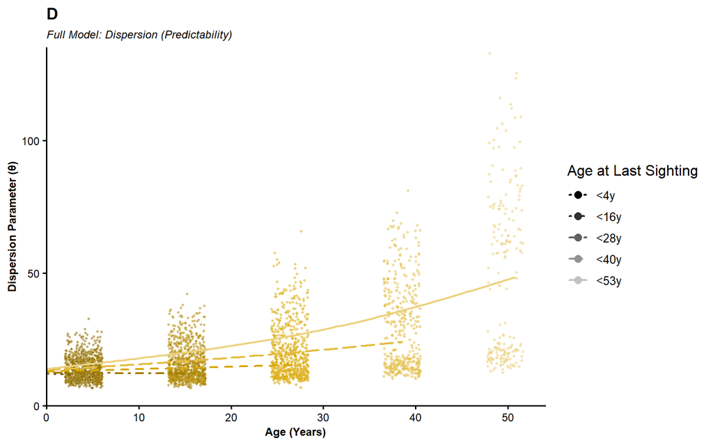

```r
# prep data by fixing bins
levels(disp_draws$alsbins) <- c("<4y", "<16y", "<28y", "<40y", "<53y")

# set breaks for jittered points
# slightly offset from geom lines for visual balance
agebreaks2 = disp_draws %>%
  filter(Age == c("1481","5553.75","9626.49999999999","14069.5","18142.25"))


# set colour palettes to ensure lines lay out correctly
disp.cols <- c("<4y" = "#755A00",
               "<16y" = "#A37D00",
               "<28y" = "#d9a600",
               "<40y" = "#e3bc40",
               "<53y" = "#ecd280")

# plot code
dispage <- ggplot(disp_draws,
                   aes(x = Age/365,
                       y = shape,
                       colour = alsbins)) +
  geom_jitter(data = slice_sample(agebreaks2, n = 100),
              aes(fill = as.factor(Age)),
              size = 1,
              alpha = 0.5,
              width = 2,
              shape = 21,
              stroke = 0,
              show.legend = TRUE) +
  geom_smooth(aes(linetype = alsbins),
              linewidth = 0.75, lineend = "round",
              method = "gam", formula = y ~ s(x, bs = "cs", k = 4), se = FALSE, show.legend = TRUE) +
  scale_colour_manual(values = disp.cols,
                      labels = c("<4y", "<16y", "<28y", "<40y", "<53y")) +
  scale_fill_manual(values = c("#755A00", "#A37D00", "#d9a600", "#e3bc40", "#ecd280"),
                      labels = c("<4y", "<16y", "<28y", "<40y", "<53y")) +
  scale_linetype_manual(values = c(3,4,2,5,1),
                        labels = c("<4y", "<16y", "<28y", "<40y", "<53y")) +
  ggtitle('D', subtitle = "Full Model: Dispersion (Predictability)") +
  labs(x = "Age (Years)",
       y = "Dispersion Parameter (θ)",
       colour = "Age at Last Sighting",
       fill = "Age at Last Sighting",
       linetype = "Age at Last Sighting") +
   guides(color = guide_legend(override.aes = list(color = c("#000000", "#303030", "#616161", "#919191", "#C2C2C2"))),
         fill = guide_legend(override.aes = list(fill = c("#000000", "#303030", "#616161", "#919191", "#C2C2C2"),
                                                  size = 3,
                                                  alpha = 1))) +
  scale_x_continuous(expand = expansion(mult = 0)) +
  scale_y_continuous(expand = expansion(mult = 0)) +
  coord_cartesian(xlim = c(0,54), ylim = c(0,135)) +
  theme(panel.background = element_rect(fill = "transparent",
                                        linetype = 0),
        plot.background = element_rect(fill = "transparent",
                                       color = NA),
        panel.grid.major = element_blank(),
        panel.grid.minor = element_blank(),
        axis.line = element_line(colour = "black")) +
  theme(plot.title = element_text(face = "bold",
                                  size = 13),
        plot.subtitle = element_text(face = "italic",
                                     size = 9),
        axis.title = element_text(face = "bold",
                                  size = 9,
                                  colour = "black"),
        axis.text = element_text(size = 9,
                                   colour = "black"),
        text = element_text(family = "sans"))

#plot!
dispage
```

### Figure 2B (Female model)

First, we create predictions for the female model using epred and linpred draws.

```r
#using previously built sequences for both m and f
f.newdat <- expand.grid(
  z.Age = ageseq,
  z.ALS = alsseq,
  Repro.Stat = NA,
  Sex = "FEMALE")

# unscale z.Age in new dataset
f.newdat <- f.newdat %>%
  mutate(Age = ((z.Age * s) + m)) %>%
  mutate(ALS = ((z.ALS * s_als) + m_als))

# draw epred -- or expectation of the posterior, i.e E(yi) of the model formula
f.mean_draws <- mod_2 %>%
  epred_draws(newdata = f.newdat,
              re_formula = NA) %>%
  group_by(Age, ALS, .draw) %>%
  summarise(Age = mean(Age),
            ALS = mean(ALS),
            predicted = mean(.epred))

f.mean_draws <- f.mean_draws %>%
  filter(Age <= ALS) %>%
  mutate(alsbins = ALS/365) %>%
  mutate(alsbins = as.factor(alsbins))


#now repeat with dispersion components
f.disp_draws <- mod_2 %>%
  linpred_draws(newdata = f.newdat,
                dpar = "shape",
                transform = TRUE,
                re_formula = NA) %>%
  group_by(Age, ALS, .draw) %>%
  summarise(Age = mean(Age),
            predicted = mean(.linpred),
            shape = mean(shape))

f.disp_draws <- f.disp_draws %>%
  filter(Age <= ALS) %>%
  mutate(alsbins = ALS/365) %>%
  mutate(alsbins = as.factor(alsbins))

#write.csv(f.mean_draws, "data/fig2_b_draws.csv", row.names = FALSE)
#write.csv(f.disp_draws, "data/fig2_e_draws.csv", row.names = FALSE)

#to import, use the following (requires "here" package)
# f.mean_draws <- read.csv(here("FILEFOLDERNAME", "fig2_b_draws.csv"), header = TRUE, sep = ",")
# f.disp_draws <- read.csv(here("FILEFOLDERNAME", "fig2_e_draws.csv"), header = TRUE, sep = ",")
```

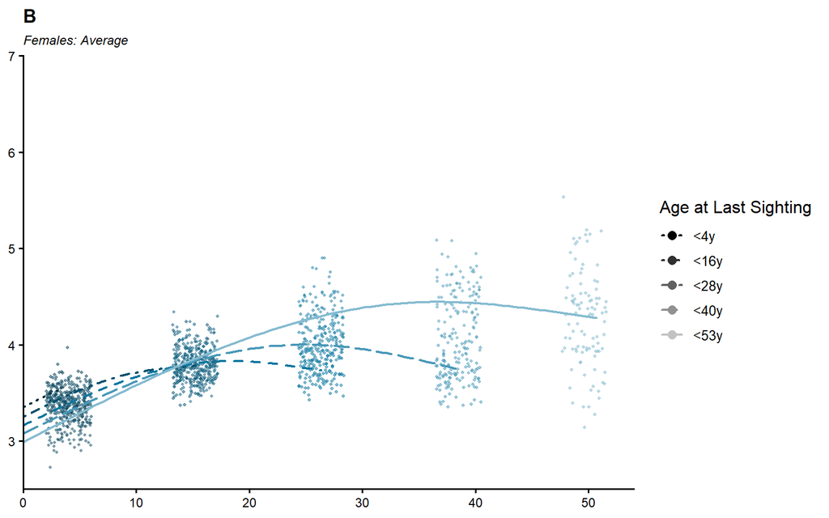

```r
# mean response level

# prep data by fixing bins
levels(f.mean_draws$alsbins) <- c("<4y", "<16y", "<28y", "<40y", "<53y")

# set breaks for jittered points
# slightly offset from lines for visual balance
f.agebreaks = f.mean_draws %>%
  filter(Age == c("1481","5553.75","9626.49999999999","14069.5","18142.25"))

# set colour palettes to ensure lines lay out correctly
f.mean.cols <- c("<4y" = "#053143",
                 "<16y" = "#08516E",
                 "<28y" = "#0b76a0",
                 "<40y" = "#4898b8",
                 "<53y" = "#85bbd0")

# plot code
f.meanage <- ggplot(f.mean_draws,
                   aes(x = Age/365,
                       y = predicted,
                       colour = alsbins)) +
  geom_jitter(data = slice_sample(f.agebreaks, n = 100),
              aes(fill = as.factor(Age)),
              size = 1,
              alpha = 0.5,
              width = 2,
              shape = 21,
              stroke = 0,
              show.legend = TRUE) +
  geom_smooth(aes(linetype = alsbins),
              linewidth = 0.75, lineend = "round",
              method = "gam", formula = y ~ s(x, bs = "cs", k = 4), se = FALSE, show.legend = TRUE) +
  scale_colour_manual(values = f.mean.cols,
                      labels = c("<4y", "<16y", "<28y", "<40y", "<53y")) +
  scale_fill_manual(values = c("#053143", "#08516E", "#0b76a0", "#4898b8", "#85bbd0"),
                      labels = c("<4y", "<16y", "<28y", "<40y", "<53y")) +
  scale_linetype_manual(values = c(3,4,2,5,1),
                      labels = c("<4y", "<16y", "<28y", "<40y", "<53y")) +
  ggtitle('B', subtitle = "Females: Average") +
  labs(colour = "Age at Last Sighting", fill = "Age at Last Sighting", linetype = "Age at Last Sighting") +
  guides(color = guide_legend(override.aes = list(color = c("#000000", "#303030", "#616161", "#919191", "#C2C2C2"))),
         fill = guide_legend(override.aes = list(fill = c("#000000", "#303030", "#616161", "#919191", "#C2C2C2"),
                                                  size = 3,
                                                  alpha = 1))) +
  scale_x_continuous(expand = expansion(mult = 0)) +
  scale_y_continuous(expand = expansion(mult = 0)) +
  coord_cartesian(xlim = c(0,54), ylim = c(2.5,7)) +
  theme(panel.background = element_rect(fill = "transparent",
                                        linetype = 0),
        plot.background = element_rect(fill = "transparent",
                                       color = NA),
        panel.grid.major = element_blank(),
        panel.grid.minor = element_blank(),
        axis.line = element_line(colour = "black")) +
  theme(plot.title = element_text(face = "bold",
                                  size = 13),
        plot.subtitle = element_text(face = "italic",
                                     size = 9),
        axis.title = element_blank(),
        axis.text = element_text(size = 9,
                                   colour = "black"),
        text = element_text(family = "sans"))


# plot!
f.meanage
```

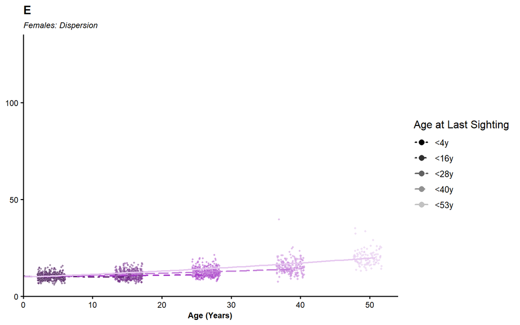

```r
#dispersion level theta/shape

# prep data by fixing bins
levels(f.disp_draws$alsbins) <- c("<4y", "<16y", "<28y", "<40y", "<53y")

# set breaks for jittered points
# slightly offset from lines for visual balance
f.agebreaks2 = f.disp_draws %>%
  filter(Age == c("1481","5553.75","9626.49999999999","14069.5","18142.25"))

# set colour palettes to ensure lines lay out correctly
f.disp.cols <- c("<4y" = "#2E1037",
                 "<16y" = "#642377",
                 "<28y" = "#A539C6",
                 "<40y" = "#C581DA",
                 "<53y" = "#E6C8EF")

# plot code
femdispage <- ggplot(f.disp_draws,
                   aes(x = Age/365,
                       y = shape,
                       colour = alsbins)) +
  geom_jitter(data = slice_sample(f.agebreaks2, n = 100),
              aes(fill = as.factor(Age)),
              size = 1,
              alpha = 0.5,
              width = 2,
              shape = 21,
              stroke = 0,
              show.legend = TRUE) +
  geom_smooth(aes(linetype = alsbins),
              linewidth = 0.75, lineend = "round",
              method = "gam", formula = y ~ s(x, bs = "cs", k = 4), se = FALSE, show.legend = TRUE) +
  scale_colour_manual(values = f.disp.cols,
                      labels = c("<4y", "<16y", "<28y", "<40y", "<53y")) +
  scale_fill_manual(values = c("#2E1037", "#642377", "#A539C6", "#C581DA", "#E6C8EF"),
                    labels = c("<4y", "<16y", "<28y", "<40y", "<53y")) +
  scale_linetype_manual(values = c(3,4,2,5,1),
                        labels = c("<4y", "<16y", "<28y", "<40y", "<53y")) +
  ggtitle('E', subtitle = "Females: Dispersion") +
  labs(x = "Age (Years)",
       colour = "Age at Last Sighting",
       fill = "Age at Last Sighting",
       linetype = "Age at Last Sighting") +
  guides(color = guide_legend(override.aes = list(color = c("#000000", "#303030", "#616161", "#919191", "#C2C2C2"))),
         fill = guide_legend(override.aes = list(fill = c("#000000", "#303030", "#616161", "#919191", "#C2C2C2"),
                                                  size = 3,
                                                  alpha = 1))) +
  scale_x_continuous(expand = expansion(mult = 0)) +
  scale_y_continuous(expand = expansion(mult = 0)) +
  coord_cartesian(xlim = c(0,54), ylim = c(0,135)) +
  theme(panel.background = element_rect(fill = "transparent",
                                        linetype = 0),
        plot.background = element_rect(fill = "transparent",
                                       color = NA),
        panel.grid.major = element_blank(),
        panel.grid.minor = element_blank(),
        axis.line = element_line(colour = "black")) +
  theme(plot.title = element_text(face = "bold",
                                  size = 13),
        plot.subtitle = element_text(face = "italic",
                                     size = 9),
        axis.title.x = element_text(face = "bold",
                                  size = 9,
                                  colour = "black"),
        axis.title.y = element_blank(),
        axis.text = element_text(size = 9,
                                   colour = "black"),
        text = element_text(family = "sans"))

# plot!
femdispage
```

We additionally plotted this figure with its default y-axis to improve readability.

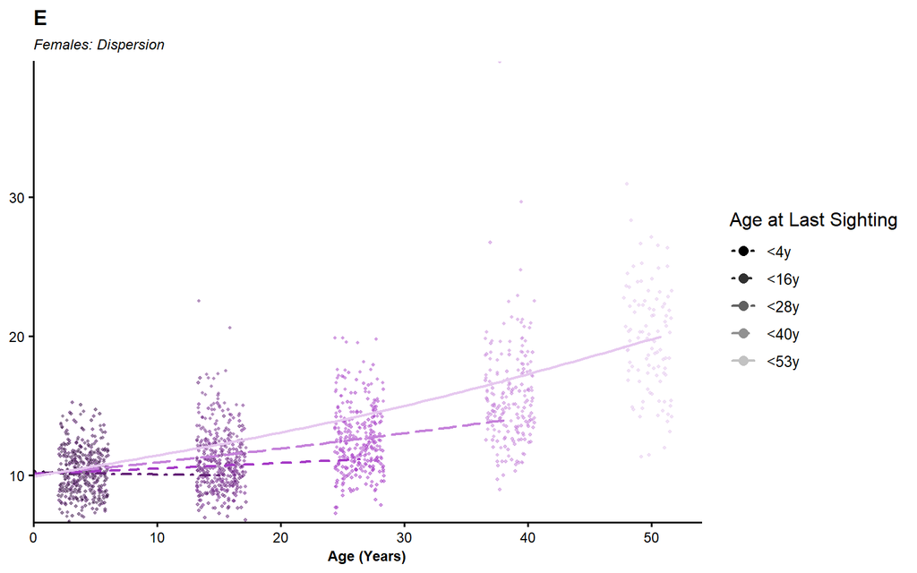

```r
#dispersion level theta/shape

# plot code
femdispage_zoom <- ggplot(f.disp_draws,
                   aes(x = Age/365,
                       y = shape,
                       colour = alsbins)) +
  geom_jitter(data = slice_sample(f.agebreaks2, n = 100),
              aes(fill = as.factor(Age)),
              size = 1,
              alpha = 0.5,
              width = 2,
              shape = 21,
              stroke = 0,
              show.legend = TRUE) +
  geom_smooth(aes(linetype = alsbins),
              linewidth = 0.75, lineend = "round",
              method = "gam", formula = y ~ s(x, bs = "cs", k = 4), se = FALSE, show.legend = TRUE) +
  scale_colour_manual(values = f.disp.cols,
                      labels = c("<4y", "<16y", "<28y", "<40y", "<53y")) +
  scale_fill_manual(values = c("#2E1037", "#642377", "#A539C6", "#C581DA", "#E6C8EF"),
                    labels = c("<4y", "<16y", "<28y", "<40y", "<53y")) +
  scale_linetype_manual(values = c(3,4,2,5,1),
                        labels = c("<4y", "<16y", "<28y", "<40y", "<53y")) +
  ggtitle('E', subtitle = "Females: Dispersion") +
  labs(x = "Age (Years)",
       colour = "Age at Last Sighting",
       fill = "Age at Last Sighting",
       linetype = "Age at Last Sighting") +
  guides(color = guide_legend(override.aes = list(color = c("#000000", "#303030", "#616161", "#919191", "#C2C2C2"))),
         fill = guide_legend(override.aes = list(fill = c("#000000", "#303030", "#616161", "#919191", "#C2C2C2"),
                                                  size = 3,
                                                  alpha = 1))) +
  scale_x_continuous(expand = expansion(mult = 0)) +
  scale_y_continuous(expand = expansion(mult = 0)) +
  coord_cartesian(xlim = c(0,54)) +
  theme(panel.background = element_rect(fill = "transparent",
                                        linetype = 0),
        plot.background = element_rect(fill = "transparent",
                                       color = NA),
        panel.grid.major = element_blank(),
        panel.grid.minor = element_blank(),
        axis.line = element_line(colour = "black")) +
  theme(plot.title = element_text(face = "bold",
                                  size = 13),
        plot.subtitle = element_text(face = "italic",
                                     size = 9),
        axis.title.x = element_text(face = "bold",
                                  size = 9,
                                  colour = "black"),
        axis.title.y = element_blank(),
        axis.text = element_text(size = 9,
                                   colour = "black"),
        text = element_text(family = "sans"))

# plot!
femdispage_zoom
```

### Figure 2C (Male model)

First, we create predictions for the male empirical using epred and linpred draws.

```r
#using previously built sequences for both m and f
m.newdat <- expand.grid(
  z.Age = ageseq,
  z.ALS = alsseq,
  Repro.Stat = NA,
  Sex = "MALE")

# unscale z.Age in new dataset
m.newdat <- m.newdat %>%
  mutate(Age = ((z.Age * s) + m)) %>%
  mutate(ALS = ((z.ALS * s_als) + m_als))

# draw epred -- or expectation of the posterior, i.e E(yi) of the model formula
m.mean_draws <- mod_2 %>%
  epred_draws(newdata = m.newdat,
              re_formula = NA) %>%
  group_by(Age, ALS, .draw) %>%
  summarise(Age = mean(Age),
            ALS = mean(ALS),
            predicted = mean(.epred))

m.mean_draws <- m.mean_draws %>%
  filter(Age <= ALS) %>%
  mutate(alsbins = ALS/365) %>%
  mutate(alsbins = as.factor(alsbins))



#now repeat with dispersion components
m.disp_draws <- mod_2 %>%
  linpred_draws(newdata = m.newdat,
                dpar = "shape",
                transform = TRUE,
                re_formula = NA) %>%
  group_by(Age, ALS, .draw) %>%
  summarise(Age = mean(Age),
            predicted = mean(.linpred),
            shape = mean(shape))

m.disp_draws <- m.disp_draws %>%
  filter(Age <= ALS) %>%
  mutate(alsbins = ALS/365) %>%
  mutate(alsbins = as.factor(alsbins))

#write.csv(m.mean_draws, "data/fig2_c_draws.csv", row.names = FALSE)
#write.csv(m.disp_draws, "data/fig2_f_draws.csv", row.names = FALSE)

#to import, use the following (requires "here" package)
# m.mean_draws <- read.csv(here("FILEFOLDERNAME", "fig2_c_draws.csv"), header = TRUE, sep = ",")
# m.disp_draws <- read.csv(here("FILEFOLDERNAME", "fig2_f_draws.csv"), header = TRUE, sep = ",")
```

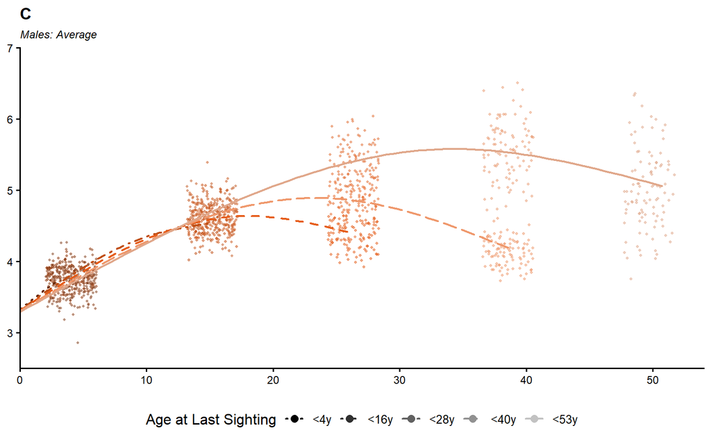

```r
# mean response level

# prep data by fixing bins
#m.mean_draws$alsbins <- factor(m.mean_draws$alsbins, levels = rev(levels(m.mean_draws$alsbins)))
levels(m.mean_draws$alsbins) <- c("<4y", "<16y", "<28y", "<40y", "<53y")

# set breaks for jittered points
# slightly offset from geom lines for visual balance
m.agebreaks = m.mean_draws %>%
  filter(Age == c("1481","5553.75","9626.49999999999","14069.5","18142.25"))

# set colour palettes to ensure lines lay out correctly
m.mean.cols <- c("<4y" = "#6A2B0C",
                 "<16y" = "#C04F15",
                 "<28y" = "#E65D1A",
                 "<40y" = "#EF986C",
                 "<53y" = "#e0a78a")

# plot code
m.meanage <- ggplot(m.mean_draws,
                   aes(x = Age/365,
                       y = predicted,
                       colour = alsbins)) +
  geom_jitter(data = slice_sample(m.agebreaks, n = 100),
              aes(fill = as.factor(Age)),
              size = 1,
              alpha = 0.5,
              width = 2,
              shape = 21,
              stroke = 0,
              show.legend = TRUE) +
  geom_smooth(aes(linetype = alsbins),
              linewidth = 0.75, lineend = "round",
  method = "gam", formula = y ~ s(x, bs = "cs", k = 4), se = FALSE, show.legend = TRUE) +
  scale_colour_manual(values = m.mean.cols,
                      labels = c("<4y", "<16y", "<28y", "<40y", "<53y")) +
  scale_fill_manual(values = c("#6A2B0C", "#C04F15", "#E65D1A", "#EF986C", "#e0a78a"),
                    labels = c("<4y", "<16y", "<28y", "<40y", "<53y")) +
  scale_linetype_manual(values = c(3,4,2,5,1),
                        labels = c("<4y", "<16y", "<28y", "<40y", "<53y")) +
  ggtitle('C', subtitle = "Males: Average") +
  labs(colour = "Age at Last Sighting", fill = "Age at Last Sighting", linetype = "Age at Last Sighting") +
  guides(color = guide_legend(override.aes = list(color = c("#000000", "#303030", "#616161", "#919191", "#C2C2C2"))),
         fill = guide_legend(override.aes = list(fill = c("#000000", "#303030", "#616161", "#919191", "#C2C2C2"),
                                                  size = 3,
                                                  alpha = 1))) +
  scale_x_continuous(expand = expansion(mult = 0)) +
  scale_y_continuous(expand = expansion(mult = 0)) +
  coord_cartesian(xlim = c(0,54), ylim = c(2.5,7)) +
  theme(panel.background = element_rect(fill = "transparent",
                                        linetype = 0),
        plot.background = element_rect(fill = "transparent",
                                       color = NA),
        panel.grid.major = element_blank(),
        panel.grid.minor = element_blank(),
        axis.line = element_line(colour = "black")) +
  theme(plot.title = element_text(face = "bold",
                                  size = 13),
        plot.subtitle = element_text(face = "italic",
                                     size = 9),
        axis.title = element_blank(),
        axis.text = element_text(size = 9,
                                   colour = "black"),
        text = element_text(family = "sans")) +
  theme(legend.position = "bottom")

# plot!
m.meanage
```

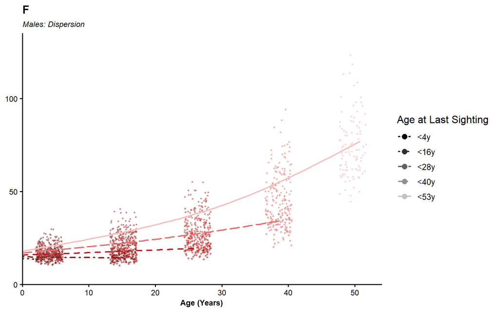

```r
#dispersion level theta/shape

# prep data by fixing bins
levels(m.disp_draws$alsbins) <- c("<4y", "<16y", "<28y", "<40y", "<53y")

# set breaks for jittered points
# slightly offset from geom lines for visual balance
m.agebreaks2 = m.disp_draws %>%
  filter(Age == c("1481","5553.75","9626.49999999999","14069.5","18142.25"))

# set colour palettes to ensure lines lay out correctly
m.disp.cols <- c("<4y" = "#700F0F",
                 "<16y" = "#901414",
                 "<28y" = "#B81919",
                 "<40y" = "#EB6F6F",
                 "<53y" = "#F6C0C0")

# plot code
maledispage <- ggplot(m.disp_draws,
                   aes(x = Age/365,
                       y = shape,
                       colour = alsbins)) +
  geom_jitter(data = slice_sample(m.agebreaks2, n = 100),
              aes(fill = as.factor(Age)),
              size = 1,
              alpha = 0.5,
              width = 2,
              shape = 21,
              stroke = 0,
              show.legend = TRUE) +
  geom_smooth(aes(linetype = alsbins),
              linewidth = 0.75, lineend = "round",
              method = "gam", formula = y ~ s(x, bs = "cs", k = 4), se = FALSE, show.legend = TRUE) +
  scale_colour_manual(values = m.disp.cols,
                      labels = c("<4y", "<16y", "<28y", "<40y", "<53y")) +
  scale_fill_manual(values = c("#700F0F", "#901414", "#B81919", "#EB6F6F", "#F6C0C0"),
                    labels = c("<4y", "<16y", "<28y", "<40y", "<53y")) +
  scale_linetype_manual(values = c(3,4,2,5,1),
                        labels = c("<4y", "<16y", "<28y", "<40y", "<53y")) +
  ggtitle('F', subtitle = "Males: Dispersion ") +
  labs(x = "Age (Years)",
       colour = "Age at Last Sighting",
       fill = "Age at Last Sighting",
       linetype = "Age at Last Sighting") +
   guides(color = guide_legend(override.aes = list(color = c("#000000", "#303030", "#616161", "#919191", "#C2C2C2"))),
          fill = guide_legend(override.aes = list(fill = c("#000000", "#303030", "#616161", "#919191", "#C2C2C2"),
                                                  size = 3,
                                                  alpha = 1))) +
  scale_x_continuous(expand = expansion(mult = 0)) +
  scale_y_continuous(expand = expansion(mult = 0)) +
  coord_cartesian(xlim = c(0,54), ylim = c(0,135)) +
  theme(panel.background = element_rect(fill = "transparent",
                                        linetype = 0),
        plot.background = element_rect(fill = "transparent",
                                       color = NA),
        panel.grid.major = element_blank(),
        panel.grid.minor = element_blank(),
        axis.line = element_line(colour = "black")) +
  theme(plot.title = element_text(face = "bold",
                                  size = 13),
        plot.subtitle = element_text(face = "italic",
                                     size = 9),
        axis.title.x = element_text(face = "bold",
                                  size = 9,
                                  colour = "black"),
        axis.title.y = element_blank(),
        axis.text = element_text(size = 9,
                                   colour = "black"),
        text = element_text(family = "sans"))

# plot!
maledispage
```

### Combine plots

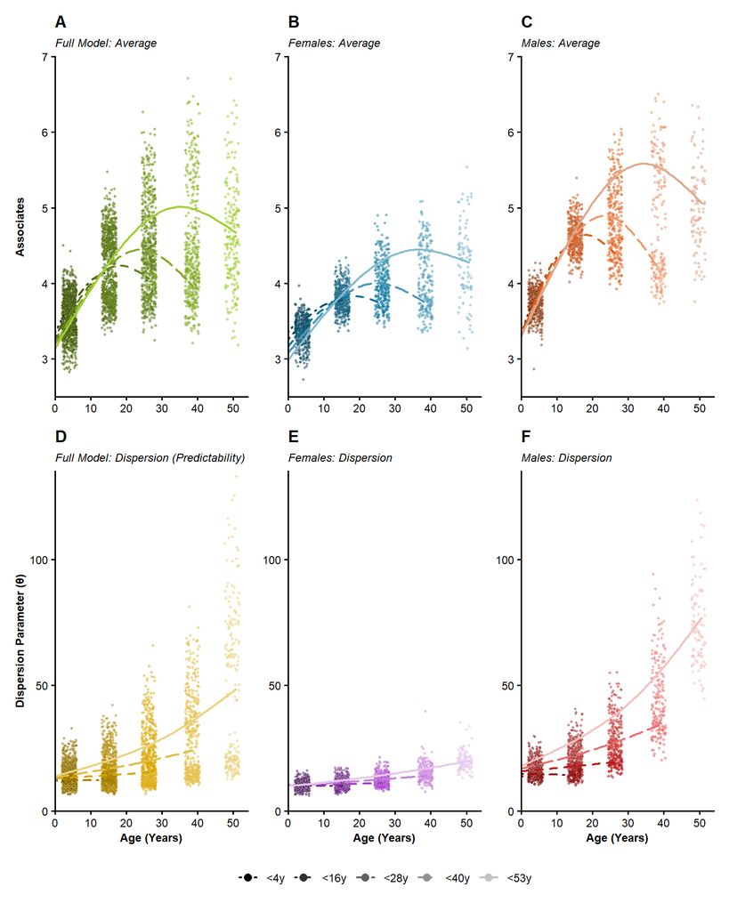

```r
fig2layout <- "
  ABC
  ABC
  DEf
  DEf
"
A = meanage
B = f.meanage
C = m.meanage
D = dispage
E = femdispage
f = maledispage

figure2 <- wrap_plots(A = A,
                      B = B,
                      C = C,
                      D = D,
                      E = E,
                      f = f,
                      design = fig2layout) + plot_layout(guides = "collect") & theme(legend.position = "bottom",
                                                                                     legend.title = element_blank(),
                                                                                     legend.text = element_text(size = 9, colour = "black"))

figure2
```

```r
#ggsave(figure2, filename = here("figures", "Fig2.tiff"), bg = "transparent", device = 'tiff', height = 22, width = 17.5, units = "cm", compression = "lzw")
```

## Figure 3

### Figure 3 (Extract all draws)

```r
# create new sequence of data to predict on from the model
allseq <- seq_range(dat$z.Age, n = 54) #  points per year approximately

# needed to unscale z.Age
m = mean(dat$ObsAge)
s <- sd(dat$ObsAge)

#create new sequence of ALS data to predict on from the model
alsseq <- seq_range(dat$z.ALS, n = 54, expand = 0.15)

# needed to unscale ALS
m_als <- mean(dat$ALS)
s_als <- sd(dat$ALS)

# creating lists of dolphin ids
# predictions are done separately to prevent computational waste on generation predictions for inaccurate sexes
femdolphins <- levels(females$Dolphin.ID)
maledolphins <- levels(males$Dolphin.ID)

#create new datasets to plug into
f.epred_dat <- expand.grid(
  z.Age = allseq,
  z.ALS = alsseq,
  Sex = "FEMALE",
  Repro.Stat = NA,
  Dolphin.ID = femdolphins,
  Observation.Date = NA,
  Year = NA) %>%
  mutate(Age = ((z.Age * s) + m)) %>%
  mutate(ALS = ((z.ALS * s_als) + m_als))

m.epred_dat <- expand.grid(
  z.Age = allseq,
  z.ALS = alsseq,
  Sex = "MALE",
  Repro.Stat = NA,
  Dolphin.ID = maledolphins,
  Observation.Date = NA,
  Year = NA) %>%
  mutate(Age = ((z.Age * s) + m)) %>%
  mutate(ALS = ((z.ALS * s_als) + m_als))

# predict expected effects for individuals.

fem_dolphin_epred_draws <- mod_2 %>%
  epred_draws(newdata = f.epred_dat,
              re_formula = NULL,
              allow_new_levels = TRUE,
              ndraws = 20) %>%
  group_by(Dolphin.ID, Age, ALS, .draw) %>%
  summarise(Age = mean(Age),
            ALS = mean(ALS),
            predicted = .epred)

# this is to check existing ALS for selecting assorted dolphins for the next plots
f.id_als <- females %>%
  select(Dolphin.ID,
         Sex,
         ALS) %>%
  distinct() %>%
  mutate(yls = ALS/365) %>%
  rename(alstrue = ALS)

fem_dolphin_epred_draws <- fem_dolphin_epred_draws %>%
  left_join(f.id_als, by = c("Dolphin.ID")) %>%
  group_by(Dolphin.ID) %>%
  filter(Age >= 0) %>%
  filter(Age < alstrue) %>%
  filter(abs(ALS - alstrue) <= 365) %>%
  droplevels()

# saveRDS(fem_dolphin_epred_draws, file = "fits/fem_dolphin_epred_draws.rds")

male_dolphin_epred_draws <- mod_2 %>%
  epred_draws(newdata = m.epred_dat,
              re_formula = NULL,
              allow_new_levels = TRUE,
              ndraws = 20) %>%
  group_by(Dolphin.ID, Age, ALS, .draw) %>%
  summarise(Age = mean(Age),
            ALS = mean(ALS),
            predicted = .epred)

# this is to check existing ALS for selecting assorted dolphins for the next plots
m.id_als <- males %>%
  select(Dolphin.ID,
         Sex,
         ALS) %>%
  distinct() %>%
  mutate(yls = ALS/365) %>%
  rename(alstrue = ALS)

male_dolphin_epred_draws <- male_dolphin_epred_draws %>%
  left_join(m.id_als, by = c("Dolphin.ID")) %>%
  group_by(Dolphin.ID) %>%
  filter(Age >= 0) %>%
  filter(Age < alstrue) %>%
  filter(abs(ALS - alstrue) <= 365) %>%
  droplevels()

# now repeat with dispersion components.
# what we really want here is "shape" as that is the dispersion parameter
# theta described in methodology, ie measure of variance

fem_dolphin_epred_draws_disp <- mod_2 %>%
  linpred_draws(newdata = f.epred_dat,
                re_formula = NULL,
                allow_new_levels = TRUE,
                dpar = "shape",
                transform = TRUE,
                ndraws = 20) %>%
  group_by(Dolphin.ID, Age, ALS, .draw) %>%
  summarise(Age = mean(Age),
            ALS = mean(ALS),
            predicted = mean(.linpred),
            shape = mean(shape))

fem_dolphin_epred_draws_disp <- fem_dolphin_epred_draws_disp %>%
  left_join(f.id_als, by = c("Dolphin.ID")) %>%
  group_by(Dolphin.ID) %>%
  filter(Age >= 0) %>%
  filter(Age < alstrue) %>%
  filter(abs(ALS - alstrue) <= 365) %>%
  droplevels()

male_dolphin_epred_draws_disp <- mod_2 %>%
  linpred_draws(newdata = m.epred_dat,
                re_formula = NULL,
                allow_new_levels = TRUE,
                dpar = "shape",
                transform = TRUE,
                ndraws = 20) %>%
  group_by(Dolphin.ID, Age, ALS, .draw) %>%
  summarise(Age = mean(Age),
            ALS = mean(ALS),
            predicted = mean(.linpred),
            shape = mean(shape))

male_dolphin_epred_draws_disp <- male_dolphin_epred_draws_disp %>%
  left_join(m.id_als, by = c("Dolphin.ID")) %>%
  group_by(Dolphin.ID) %>%
  filter(Age >= 0) %>%
  filter(Age < alstrue) %>%
  filter(abs(ALS - alstrue) <= 365) %>%
  droplevels()
```

```r
head(fem_dolphin_epred_draws)
```

| Dolphin.ID | Age | ALS | .draw | predicted | Sex | alstrue | yls |
| --- | --- | --- | --- | --- | --- | --- | --- |
| ALG | 0 | 12196.32 | 1 | 4.2661148 | FEMALE | 12235 | 33.52055 |
| ALG | 0 | 12196.32 | 2 | 0.8763649 | FEMALE | 12235 | 33.52055 |
| ALG | 0 | 12196.32 | 3 | 5.6609566 | FEMALE | 12235 | 33.52055 |
| ALG | 0 | 12196.32 | 4 | 5.8954382 | FEMALE | 12235 | 33.52055 |
| ALG | 0 | 12196.32 | 5 | 3.5386950 | FEMALE | 12235 | 33.52055 |
| ALG | 0 | 12196.32 | 6 | 2.7774569 | FEMALE | 12235 | 33.52055 |

```r
head(fem_dolphin_epred_draws_disp)
```

| Dolphin.ID | Age | ALS | .draw | predicted | shape | Sex | alstrue | yls |
| --- | --- | --- | --- | --- | --- | --- | --- | --- |
| ALG | 0 | 12196.32 | 1 | 8.420565 | 1.414976e+03 | FEMALE | 12235 | 33.52055 |
| ALG | 0 | 12196.32 | 2 | 14.570996 | 8.698442e-02 | FEMALE | 12235 | 33.52055 |
| ALG | 0 | 12196.32 | 3 | 1.733670 | 4.699297e+01 | FEMALE | 12235 | 33.52055 |
| ALG | 0 | 12196.32 | 4 | 1.537189 | 1.078069e+03 | FEMALE | 12235 | 33.52055 |
| ALG | 0 | 12196.32 | 5 | 4.494938 | 6.180846e+00 | FEMALE | 12235 | 33.52055 |
| ALG | 0 | 12196.32 | 6 | 2.959937 | 4.449221e+01 | FEMALE | 12235 | 33.52055 |

```r
head(male_dolphin_epred_draws)
```

| Dolphin.ID | Age | ALS | .draw | predicted | Sex | alstrue | yls |
| --- | --- | --- | --- | --- | --- | --- | --- |
| ABC | 0 | 10989.6 | 1 | 1.971686 | MALE | 10987 | 30.10137 |
| ABC | 0 | 10989.6 | 2 | 4.898169 | MALE | 10987 | 30.10137 |
| ABC | 0 | 10989.6 | 3 | 3.486318 | MALE | 10987 | 30.10137 |
| ABC | 0 | 10989.6 | 4 | 2.928868 | MALE | 10987 | 30.10137 |
| ABC | 0 | 10989.6 | 5 | 3.042650 | MALE | 10987 | 30.10137 |
| ABC | 0 | 10989.6 | 6 | 3.872503 | MALE | 10987 | 30.10137 |

```r
head(male_dolphin_epred_draws_disp)
```

| Dolphin.ID | Age | ALS | .draw | predicted | shape | Sex | alstrue | yls |
| --- | --- | --- | --- | --- | --- | --- | --- | --- |
| ABC | 0 | 10989.6 | 1 | 3.6865866 | 0.5652402 | MALE | 10987 | 30.10137 |
| ABC | 0 | 10989.6 | 2 | 2.6810614 | 8.5749173 | MALE | 10987 | 30.10137 |
| ABC | 0 | 10989.6 | 3 | 2.8552975 | 37.9548820 | MALE | 10987 | 30.10137 |
| ABC | 0 | 10989.6 | 4 | 4.3025653 | 6.2689799 | MALE | 10987 | 30.10137 |
| ABC | 0 | 10989.6 | 5 | 6.6667347 | 4.2228714 | MALE | 10987 | 30.10137 |
| ABC | 0 | 10989.6 | 6 | 0.6224319 | 403.8841376 | MALE | 10987 | 30.10137 |

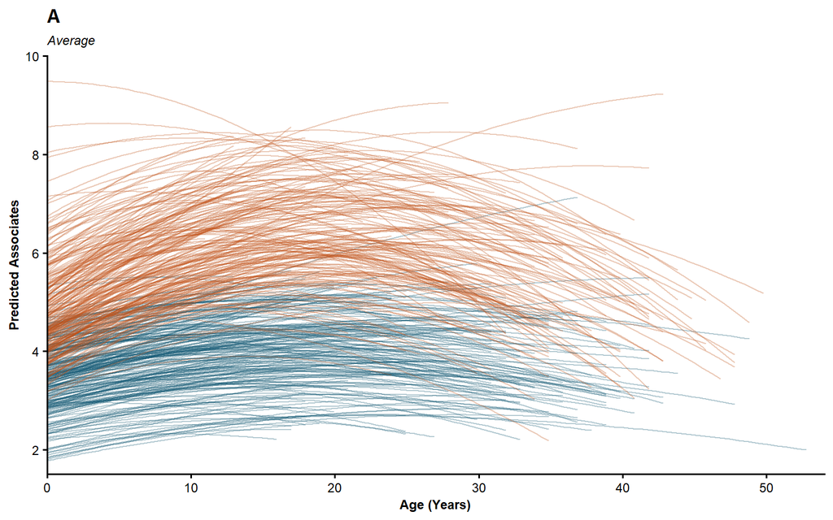

```r
draws_dat <- rbind(fem_dolphin_epred_draws, male_dolphin_epred_draws)

#write.csv(draws_dat, "data/fig3_mean_draws.csv", row.names = FALSE)

#to import, use the following (requires "here" package)
# draws_dat <- read.csv(here("FILEFOLDERNAME", "fig3_mean_draws.csv"), header = TRUE, sep = ",")

# plot average draws
draws_plot <- ggplot(draws_dat,
                   aes(x = Age/365,
                       y = predicted,
                       color = Sex,
                       group = Dolphin.ID)) +
  stat_smooth(geom = "line", alpha = 0.3,
            linewidth = 0.4, lineend = "round",
            method = "gam", formula = y ~ poly(x,2), show.legend = FALSE)+
  ggtitle('A', subtitle = "Average ") +
  labs(x = "Age (Years)",
       y = "Predicted Associates") +
   scale_colour_manual(values = c("#08516E", "#C04F15"),
                      labels = c("Females", "Males")) +
  scale_x_continuous(expand = expansion(mult = 0)) +
  scale_y_continuous(expand = expansion(mult = 0)) +
  coord_cartesian(xlim = c(0,54), ylim = c(1.5,10)) +
  theme(panel.background = element_rect(fill = "transparent",
                                        linetype = 0),
        plot.background = element_rect(fill = "transparent",
                                       color = NA),
        panel.grid.major = element_blank(),
        panel.grid.minor = element_blank(),
        axis.line = element_line(colour = "black")) +
  theme(plot.title = element_text(face = "bold",
                                  size = 13),
        plot.subtitle = element_text(face = "italic",
                                     size = 9),
        axis.title = element_text(face = "bold",
                                  size = 9,
                                  colour = "black"),
        axis.text = element_text(size = 9,
                                   colour = "black"),
        text = element_text(family = "sans"))

draws_plot
```

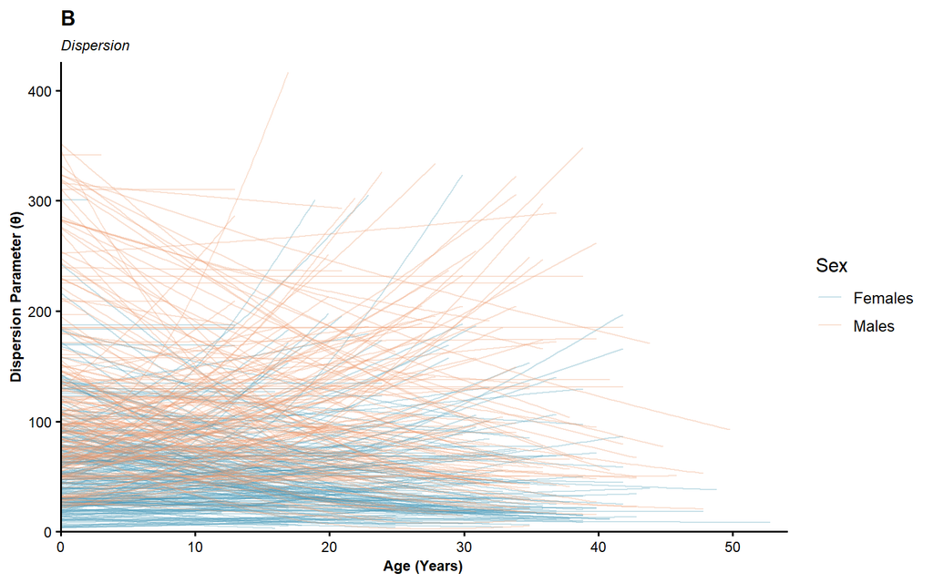

```r
disp_dat <- rbind(fem_dolphin_epred_draws_disp, male_dolphin_epred_draws_disp)

#write.csv(disp_dat, "data/fig3_disp_draws.csv", row.names = FALSE)

#to import, use the following (requires "here" package)
# disp_dat <- read.csv(here("FILEFOLDERNAME", "fig3_disp_draws.csv"), header = TRUE, sep = ",")


# this filter is applied to reduce extreme lines and make interpretation more broadly visible
visfilter <- disp_dat %>%
  group_by(Dolphin.ID) %>%
  filter(max(shape) < 3500)

# plot disp draws
disp_plot <- ggplot(visfilter,
                   aes(x = Age/365,
                       y = shape,
                       color = Sex,
                       group = Dolphin.ID)) +
  stat_smooth(geom = "line", alpha = 0.3,
            linewidth = 0.4, lineend = "round",
            method = "gam", formula = y ~ s(x, bs = "cs", k = 3), show.legend = TRUE)+
  ggtitle('B', subtitle = "Dispersion") +
  labs(x = "Age (Years)",
       y = "Dispersion Parameter (θ)") +
  scale_colour_manual(values = c("#4898b8", "#EF986C"),
                      labels = c("Females", "Males")) +
  scale_x_continuous(expand = expansion(mult = 0)) +
  scale_y_continuous(expand = expansion(mult = 0)) +
  coord_cartesian(xlim = c(0,54), ylim = c(0,425)) +
  theme(panel.background = element_rect(fill = "transparent",
                                        linetype = 0),
        plot.background = element_rect(fill = "transparent",
                                       color = NA),
        panel.grid.major = element_blank(),
        panel.grid.minor = element_blank(),
        axis.line = element_line(colour = "black")) +
  theme(plot.title = element_text(face = "bold",
                                  size = 13),
        plot.subtitle = element_text(face = "italic",
                                     size = 9),
        axis.title = element_text(face = "bold",
                                  size = 9,
                                  colour = "black"),
        axis.text = element_text(size = 9,
                                   colour = "black"),
        text = element_text(family = "sans"))



disp_plot
```

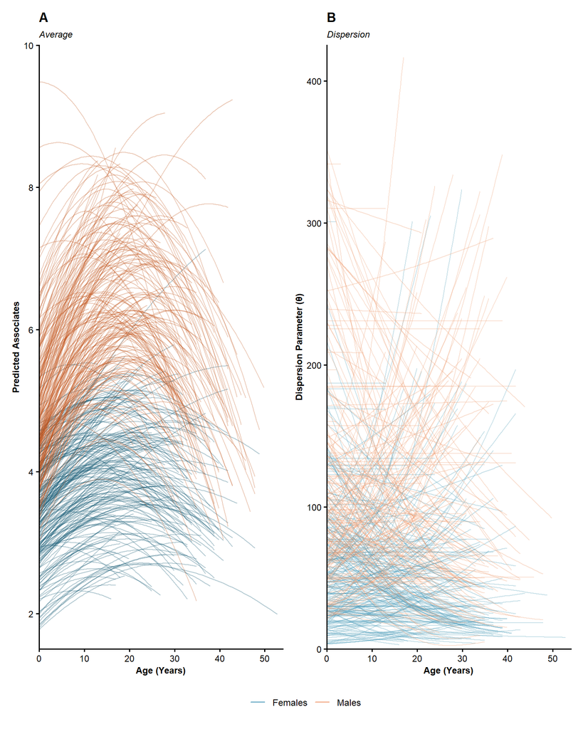

```r
fig3layout <- "
  AB
  AB
"
A = draws_plot
B = disp_plot


figure3 <- wrap_plots(A = A,
                      B = B,
                      design = fig3layout) +
  plot_layout(guides = "collect") +
  guides(colour = guide_legend(override.aes = list(alpha = 1))) &
  theme(legend.position = "bottom",
        legend.title = element_blank(),
        legend.text = element_text(size = 9, colour = "black"))

figure3
```

```r
#ggsave(figure3, filename = here("figures", "Fig3.tiff"), bg = "transparent", device = 'tiff', height = 18, width = 18, units = "cm", compression = "lzw")
```

## Figure 4

### Figure 4A (Latent Response)

```r
# figure out where the requisite variables are
options(max.print = 2000)
head(get_variables(mod_2),2000)
# "r_Dolphin.ID[XXX,Intercept]"   runs from 48 to 504
# "r_Dolphin.ID__shape[XXX,Intercept]"    runs from 1419 to 1875
# codes are ABC to ZOE
```

```r
#create table of draws
mean.id.posterior <- as_draws_df(mod_2)[,48:504] %>% #this throws a warning but it works
  gather(Dolphin.ID, value,
         "r_Dolphin.ID[ABC,Intercept]" : "r_Dolphin.ID[ZUF,Intercept]") %>% # replace with anon_id and codes
  separate(Dolphin.ID, c(NA,NA,"Dolphin.ID", NA, NA),
           sep = "([\\_\\[\\,])", fill = "right")

# need to add sex into this for colour
datsex <- dat %>%
  select(Dolphin.ID, #anon_id
         Sex) %>%
  distinct(Dolphin.ID, .keep_all = T) #remember to reduce to one row per animal lol

mean.id.posterior.s <- left_join(mean.id.posterior, datsex, by = "Dolphin.ID")

mean.id.posterior.s <- mean.id.posterior.s %>%
  group_by(Dolphin.ID) %>%
  mutate(medval.s = median(value))%>%
  rename(value.s = value) %>%
  ungroup()

#write.csv(mean.id.posterior.s, "data/fig4_a.csv", row.names = FALSE)

#to import, use the following (requires "here" package)
# mean.id.posterior.s <- read.csv(here("FILEFOLDERNAME", "fig4_a.csv"), header = TRUE, sep = ",")
```

```r
mean.id.plot <- ggplot(mean.id.posterior.s,
                       aes(x = value.s,
                           y = reorder(Dolphin.ID, medval.s),
                           colour = Sex,
                           fill = Sex)) +
  stat_pointinterval(.width = 0.95, linewidth = 0.01, point_size = 0.1, alpha = 0.7) +
  scale_colour_manual(values = c("#0B76A0", "#C04F15")) + # specifies CI colours
  labs(x = "Mean Sociability (Log)",
       y = "Dolphin ID") +
  ggtitle("A", subtitle = "Individual Mean Sociability") +
  theme(axis.line = element_line(colour = "black"),
        panel.grid = element_blank(),
        axis.ticks.y = element_blank(),
        axis.text.y = element_blank(),
        panel.background = element_rect(fill = "transparent",
                                        colour = NA),
        plot.background = element_rect(fill = "transparent",
                                       color = NA),
        legend.position = "none",
        legend.background = element_rect(fill = "transparent")) +
  theme(plot.title = element_text(face = "bold",
                                  size = 13),
        plot.subtitle = element_text(face = "italic",
                                     size = 9),
        axis.title = element_text(face = "bold",
                                  size = 9,
                                  colour = "black"),
        axis.text = element_text(size = 9,
                                 colour = "black"),
        text = element_text(family = "sans"))
```

### Figure 4B (Predictability)

```r
pred.id.posterior <- as_draws_df(mod_2)[,1419:1875] %>%
  gather(Dolphin.ID, value,
         "r_Dolphin.ID__shape[ABC,Intercept]" : "r_Dolphin.ID__shape[ZUF,Intercept]") %>%
  separate(Dolphin.ID, c(NA,NA,NA, NA, "Dolphin.ID", NA),
           sep = "([\\_\\__\\[\\,])", fill = "right")


pred.id.posterior.s <- left_join(pred.id.posterior, datsex, by = "Dolphin.ID")

pred.id.posterior.s <- pred.id.posterior.s %>%
  group_by(Dolphin.ID) %>%
  mutate(medval.p = median(value))%>%
  rename(value.p = value) %>%
  ungroup()

# write.csv(pred.id.posterior.s, "data/fig4_b.csv", row.names = FALSE)

# to import, use the following (requires "here" package)
# pred.id.posterior.s <- read.csv(here("FILEFOLDERNAME", "fig4_b.csv"), header = TRUE, sep = ",")
```

```r
pred.id.plot <- ggplot(pred.id.posterior.s,
                       aes(y = reorder(Dolphin.ID, medval.p),
                           x = value.p,
                           colour = Sex,
                           fill = Sex)) +
  stat_pointinterval(.width = 0.95, linewidth = 0.01, point_size = 0.1, alpha = 0.7) +
  scale_colour_manual(values = c("#0B76A0", "#C04F15")) + # specifies CI colours
  labs(x = "Social Predictability (Log)",
       y = "Dolphin ID") +
  ggtitle("B", subtitle = "Individual Social Predictability") +
  theme(axis.line = element_line(colour = "black"),
        panel.grid = element_blank(),
        axis.ticks.y = element_blank(),
        axis.text.y = element_blank(),
        panel.background = element_rect(fill = "transparent",
                                        colour = NA),
        plot.background = element_rect(fill = "transparent",
                                       color = NA),
        legend.position = "bottom",
        legend.background = element_rect(fill = "transparent")) +
  theme(plot.title = element_text(face = "bold",
                                  size = 13),
        plot.subtitle = element_text(face = "italic",
                                     size = 9),
        axis.title = element_text(face = "bold",
                                  size = 9,
                                  colour = "black"),
        axis.text = element_text(size = 9,
                                 colour = "black"),
        text = element_text(family = "sans"))
```

### Figure 4C (Correlation)

```r
#summary stats for plots
soc.mean.sum <- mean.id.posterior.s %>%
  group_by(Dolphin.ID) %>%
  summarise(mean.pos.s = mean(value.s, na.rm = TRUE),
            med.pos.s = median(value.s, na.rm = TRUE),
            sd.pos.s = sd(value.s, na.rm = TRUE),
            n.pos.s = n()) %>%
  mutate(lower.ci.pos.s = mean.pos.s - sd.pos.s,
         upper.ci.pos.s = mean.pos.s + sd.pos.s)

soc.pred.sum <- pred.id.posterior.s %>%
  group_by(Dolphin.ID) %>%
  summarise(mean.pos.p = mean(value.p, na.rm = TRUE),
            med.pos.p = median(value.p, na.rm = TRUE),
            sd.pos.p = sd(value.p, na.rm = TRUE),
            n.pos.p = n()) %>%
  mutate(lower.ci.pos.p = mean.pos.p - sd.pos.p,
         upper.ci.pos.p = mean.pos.p + sd.pos.p)

#### correlations table ####
soc.pred.corr <- purrr::reduce(list(soc.mean.sum, soc.pred.sum, datsex),
                               dplyr::left_join, by = "Dolphin.ID") # anon_id

# write.csv(soc.pred.corr, "data/fig4_c.csv", row.names = FALSE)

# to import, use the following (requires "here" package)
# soc.pred.corr <- read.csv(here("FILEFOLDERNAME", "fig4_c.csv"), header = TRUE, sep = ",")
```

```r
corr.id.plot <- ggplot(soc.pred.corr,
                       aes(x = med.pos.s,
                           y = med.pos.p,
                           colour = Sex)) +
  scale_colour_manual(values = c("#0B76A0", "#C04F15")) + # specifies CI colours
  labs(x = "Mean Sociability (Log)",
       y = "Social Predictability (Log)") +
  geom_point(size = 0.1) +
  geom_errorbar(aes(ymin = lower.ci.pos.p,  #this one for predictability error bars
                    ymax = upper.ci.pos.p),
                alpha = 0.7, #this will look too dark normally but appears well in ggsave figure
                linewidth = 0.075) +
  geom_errorbarh(aes(xmin = lower.ci.pos.s,#this one for mean sociality error bars
                     xmax = upper.ci.pos.s),
                 alpha = 0.75,
                 linewidth = 0.075) +
  ggtitle("C", subtitle = "Correlation") +
  theme(axis.line = element_line(colour = "black"),
        panel.grid = element_blank(),
        panel.background = element_rect(fill = "transparent",
                                        colour = NA),
        plot.background = element_rect(fill = "transparent",
                                       color = NA),
        legend.position = "none",
        legend.background = element_rect(fill = "transparent")) +
  theme(plot.title = element_text(face = "bold",
                                  size = 13),
        plot.subtitle = element_text(face = "italic",
                                     size = 9),
        axis.title = element_text(face = "bold",
                                  size = 9,
                                  colour = "black"),
        axis.text = element_text(size = 9,
                                 colour = "black"),
        text = element_text(family = "sans"))
```

### Combine plots

```r
a4 <- mean.id.plot + guides()

b4 <- pred.id.plot + guides()

c4 <- corr.id.plot + guides(colour = "none")

figure4 <- a4 + b4 + c4 +
  plot_layout(guides = "collect") &
  theme(legend.position = "bottom",
        legend.background = element_rect(colour = "transparent"))
```

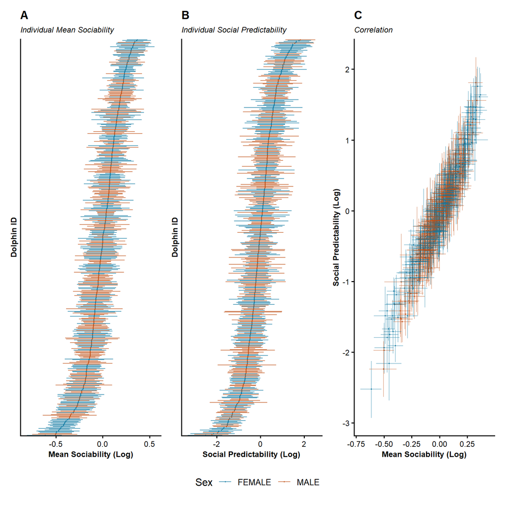

```r
figure4
```

```r
#ggsave(figure4, filename = here("figures", "Fig4.tiff"), bg = "transparent", device = 'tiff', height = 14, width = 18, units = "cm", dpi = 300, compression = "lzw")
```

[session information not shown]